# Python pro studenty Aplikované informatiky

### ⓒ Jiří Fišer, MMXX, Přírodovědecká fakulta, UJEP, Ústí nad Labem

[figure not shown]

- Programování a Python ([Jupyter](https://colab.research.google.com/github/JiriFiser/python-conda_pip/blob/master/python-nb-1AB.ipynb))
- Co je programování?
- Proč právě Python?
- Co pro programování v Pythonu potřebujete?
- Základní syntaxe Pythonu
- Objekty a proměnné ([Jupyter](https://colab.research.google.com/github/JiriFiser/python-conda_pip/blob/master/python-nb-2AB.ipynb))
- Základní objekty
- Proměnné
- Matematické funkce
- Podmínky a větvení programu ([Jupyter](https://colab.research.google.com/github/JiriFiser/python-conda_pip/blob/master/python-nb-3AB.ipynb))
- Pravdivostní hodnoty
- Speciální hodnoty (ne-hodnoty)
- Větvení programu
- Operace s řetězci
- Cykly a seznamy ([Jupyter](https://colab.research.google.com/github/JiriFiser/python-conda_pip/blob/master/python-nb-4AB.ipynb))
- Cyklus for
- Seznam
- Iterátory
- Uživatelské funkce ([Jupyter](https://colab.research.google.com/github/JiriFiser/python-conda_pip/blob/master/python-nb-5AB.ipynb))
- Rekurze
- Objektově orientované programování ([Jupyter](https://colab.research.google.com/github/JiriFiser/python-conda_pip/blob/master/python-nb-6AB.ipynb))
- Representace časových údajů
- Práce se soubory (proudy dat)
- Representace dat ([Jupyter](https://colab.research.google.com/github/JiriFiser/python-conda_pip/blob/master/python-nb-7A.ipynb))
- Časová složitost
- Množina a slovník
- Výjimky ([Jupyter](https://colab.research.google.com/github/JiriFiser/python-conda_pip/blob/master/python-nb-8A.ipynb))
- Vyhození výjimky
- Aserce (testovací tvrzení)
- Správce kontextu

# 1. Programování a Python

## Co je programování?

**Programování** je v současné češtině (resp. *coding* v současné angličtině) relativně běžné slovo. Stejně jako slova *integrál* nebo *kvantum* je však spojováno se subkulturou ne zcela normálních lidí, pro něž má angličtina slovo *nerd* (české *mimoň* není zcela přesným ekvivalentem).

```
Je to osoba vnímaná jako nadprůměrně inteligentní až obsesivní, většinou s nedostatkem sociálních dovedností. Poznávacím znamením je jejich neschopnost chápat a navazovat sociální vztahy s většinou populace.
...
Typickou pracovní náplní nerdů je programování a věda.
...
```

Česká Wikipedia, heslo `nerd` [https://cs.wikipedia.org/w/index.php?title=Nerd&oldid=15961484].

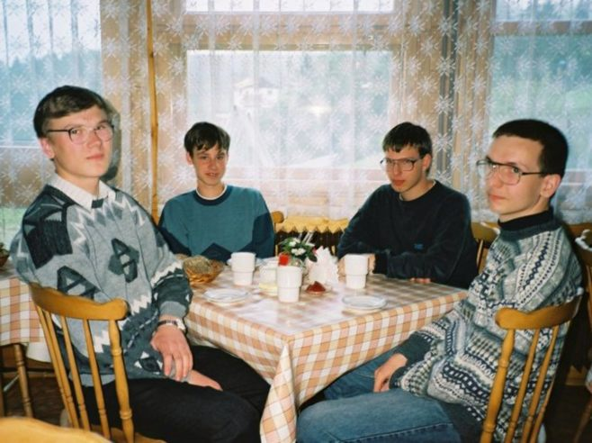

Klasická představa nerdů (tzv. "Párty na matfyzu" resp. "Brutální pařba informatiků"), skutečný kontext viz např. [forum24.cz](http://forum24.cz/jak-dopadli-chlapci-z-brutalni-parby-informatiku-2) </center>

Hlavním cílem programování však není identifikace s touto subkulturou, ale možnost lépe využívat pomoci počítačů pro řešení jednoduchých i složitějších úkolů z běžného ale především odborného života (spojení *odborný život* doufám není jen synonymum pro život nerda).

Běžní uživatelé s počítači komunikují pomocí grafických rozhraní, která obsahují různé vstupní a výstupní vizuální. To je sice možné, ale podobá se to komunikaci dospělé osoby s dítětem pomocí obrázkové knížky. Dospělé osoby navzájem komunikují pomocí velmi složitého lidského jazyka, který je v případě přírodovědně orientovaných jedinců doplněn o abstraktní terminologii a o mnohdy ještě abstraktnější matematické konstrukce (funkce, rovnice).

Pokud chcete s počítačem komunikovat na této úrovni nezbývá Vám nic jiného, než se naučit programovat tj. přepisovat svoje myšlenky do některého ze speciálních jazyků pro komunikaci s počítačem tzv. **programovacího jazyka**.

Komunikace pomocí programovacího jazyka se může na začátku jevit jako obtížná, neboť se programovací jazyky (prozatím?) výrazně odlišují od jazyků lidských. Důvodem je jiný výchozí model digitálních počítačů (aritmetické operace mezi pamětí složené z jednotlivých paměťových buněk) a jejich omezené (především) paměťové prostředky (nelze tak prozatím simulovat lidský mozek ani lidskou komunikaci). Většina programovacích jazyků je proto založena na elementárních matematických konstrukcích (jako jsou aritmetické operace a kopírování hodnot mezi paměťovými místy). Programátoři tak museli (a do značné míry stále musejí) dobře znát některé části matematiky (naštěstí dosti elementární) a především chápat interní representaci digitálních počítačů (procesory, strojový jazyk apod.).

Modernější programovací jazyky (dále jen jazyky) však nabízejí konstrukce, které jsou mnohem abstraktnější a v mnoha případech bližší lidskému myšlení (na druhé straně však v nových programovacích jazycích existují i složité koncepce, jejichž pochopení není pro člověka úplně snadné). Komunikace s počítačem tak stále ještě není komunikací mezi dvěma rovnocennými partnery, je však dostupná (a užitečná) i nenerdům.

> **Otázka:** Čím se principiálně liší programovací jazyk od matematického zápisu (notace)?

## Proč právě Python?

Stejně jako v případě přirozených jazyků (tj. jazyků určených pro komunikaci člověk ↔ člověk) existují i v případě jazyků programovacích (komunikace člověk ↔ počítač) tisíce různých jazyků a jejich dialektů.

Přirozené jazyky jsou sice běžně navzájem zcela nesrozumitelné většinou však sdílejí mnoho společných koncepcí (i přes zjevnou rozdílnost angličtiny a češtiny oba jazyky sdílejí například protiklad podstatné jméno versus sloveso, koncepce předložek, gramatických osob a slovesných časů). Přirozené jazyky navíc běžně sdílejí tzv. sémantické pole (čeština a angličtina má řádově shodný počet slov, které v zásadě označují podobné entity a ideje). I když může být překlad mezi jazyky přirozenými jazyky obtížný, je v zásadě možný a délky obou jazykových verzí se řádově neliší (po přeložení textu z angličtiny do češtiny běžně nezískáme desetkrát delší text).

U programovacích jazyků je situace poněkud odlišná. Za prvé mohou vycházet ze zcela odlišných koncepcí, která se většinou označují jako tzv. **programovací paradigmata**. Některá paradigmata jsou široce rozšířena (např. tzv. strukturované nebo procedurální) jiná jsou podporovány jediným programovacím jazykem. Existují však i rysy sdílené většinou programovacích jazyků (podpora operací nad celými čísly nebo koncept označování hodnot dočasnými symboly).

Ještě větší rozdíly existují v podpoře různých druhů informací, objektů nabízených informačními technologiemi a operací nad nimi. Existují jazyky *silně specializované* (podporující často jen zcela okrajové přístupy ke zpracování informací), *jazyky teoreticky univerzální* (schopné, alespoň teoreticky zpracovat libovolné informace a přistupovat ke všem prostředků, i když mnohdy za cenu extrémně dlouhého a složitého programu), a *jazyky téměř universální* (snadno použitelné pro téměř libovolné úkoly).

Buhužel (nebo bohudík) neexistuje žádný skutečně univerzální jazyk, který by plně uspokojoval majoritu resp. alespoň výraznější minoritu programátorů (neexistuje žádná počítačová "angličtina"). Nezbývá tak nic jiného než si nějaký jazyk zvolit (na základě jeho popularity nebo maximální kompatibility s Vaším myšlením) resp. naučit se hned několik programovacích jazyků (pro profesionální programátory je to nutnost).

Pro účely tohoto studijního materiálu jsem provedl volbu za Vás a zvolil programovací jazyk **Python**. I když ani Python dokonalý má hned několik konkurenčních výhod:

- je téměř univerzální, přičemž přímo podporuje i činnosti, které vyžadují odborníci přírodovědných oborů:
  - snadné zpracování velkých dat s možností jejich vizualizace
  - podpora webových služeb (získávání a poskytování dat na Internetu)
  - možnost interaktivního využívání
- je tzv. multiparadigmatický, tj. kromě hlavního paradigmatu (je jím v současnosti nejpoužívanějšé objektové) popdporuje i další
- má velkou a aktivní komunitu uživatelů a to i mezi vědci a inženýry
- je užíván i podporován i v komerční sféře (a to i velkými firmami)
- má jednoduchou syntaxi (která je sice jedinečná, ale v zásadě se neliší od syntaxe programovacích jazyků hlavního proudu)
- pro celý dokumentace a výukové materiály pro začátečníky i pokročilé (především v angličtině, ale ani podpora v českém jazyce není špatná)

> **Otázka**: Podle čeho je pojmenován jazyk Python?
> 1. podle kobry (anglicky *python*)
> 2. podle Monty Pythonů
> 3. podle draka (hada) střežícího Delfy

> Nápověda: Logo Pythonu

[figure not shown]

## Co pro programování v Pythonu potřebujete?

Pro programování v Pythonu v zásadě potřebuje jen jedinou aplikaci: **interpret jazyka Python**, který vykonává program v Pythonu, tj. provádí jednotlivé kroky programu na procesoru a s využitím dalších prostředků počítače nebo počítačové sítě.

### Interpret jazyka

Interpret buď vykonává jednotlivé příkazy programu zadávané z konzole (*režim interaktivní*) nebo vykonává příkazy uložené v textovém souboru (tzv. skriptu) v *režimu dávkovém*. Skripty jsou vytvářeny a editovány pomocí textového editoru (může to být libovolný editor nevkládající formátovací značky jako např. `notepad`, ale častěji to bývají tzv. programátorské editory).

Instalace pythonského interpretu není triviální, neboť kromě spustitelného souboru interpret vyžaduje stovky dalších souborů – knihoven, dokumentace, pomocných skriptů a dokonce i pomocných spustitelných souborů. Proto je vhodnější nainstalovat interpret i s celou jeho podporou tzv. distribuci Pythonu.

#### Standardní distribuce Pythonu (Python Software Foundation)

Základní možností je standardní distribuce dostupná na domovských stránkách Pythonu: [Python download](https://www.python.org/downloads). Aktuální hlavní větev Pythonu je nyní Python 3 a proto stahujte nejnovější verzi v této větvi (v době psaní tohoto textu to byla verze 3.6.5).

Výhodou této distribuce je vždy nejnovější verze Pythonu a podpora velkého množství platforem (operačních systémů).

#### Intel Distribution for Python

V mnoha případech je však pohodlnější distribuce tzv. Intel Pythonu. Ta kromě optimalizací pro procesory Intel obsahuje i velké množství dodatečných knihoven, z nichž mnohé budeme dále využívat (lze je snadno doinstalovat i do standardní distribuce, ale je to pamalejší a občas se mohou vyskytnout problémy).

Distribuci Intel Pythonu najdete na stránce [Intel Distribution for Python](https://software.seek.intel.com/python-distribution). Je opět k dispozici pro Linux i Windows a v obou větvích (**opět zvolte novější Python 3!**). Pozor: tato distribuce má již při stažení velikost přes jeden gigabyte (po instalaci je to ještě více).

#### Další alternativy

Kromě výše uvedených existují i další zajímavé distribuce: [Active Python](https://www.activestate.com/activepython) resp. [Anaconda](https://www.anaconda.com/download/#linux).

V případě Linuxu je Python běžně k dispozici v balíčcích v repositářích dané linuxovské distribuce. I zde zvole balíčky pro verzi Python 3 (nejběžnější jméno je `python3`). Balíčky nemusí podporovat nejnovější verzi Pythonu (u Ubuntu 16.04, který používám je to Python 3.5).

**Navíc zde existuje možnost, jak se (lokální) instalaci Pythonu zcela vyhnout. Python je běžně nabízen jako cloudová služba, nejčastěji prostřednictvím rozhraní notebooků Jupyter (čtěte dále)**

### Interaktivní interpret

Jak bylo řečeno výše může být interpret jazyka Python využit i v interaktivní režimu. Je to však velmi nepohodlné, neboť standardní interpret jazyka Python neumožňuje ani řádkovou editace, tím spíše celoobrazovkový režim.

Z tohoto důvodu vznikl vyspělejší textově orientovaný interaktivní interpret `ipython`, který kromě řídkové editace podporuje i historii či doplňování syntaxe. Dalším vývojem *ipythonu* vznikl projekt `jupyter` (skutečně s ypsilonem, spojení `py` je jakýmsi poznávacím znamením pythonských nástrojů). *Jupyter* nabízí interaktivní dokumenty tzv. notebooky. Notebooky mohou kromě kódu, textového vstupu a výstupu zobrazovat i grafiku resp. strukturované texty.

Pomocí *Jupyterovského* notebooku (dále jen notebook) je vytvořen i tento dokument a budeme jej využívat i nadále pro komentované ukázky kratších pythonských kódů. Můžete jej sa mozřejmě využívat jako jakousi vylepšenou pythonského kalkulačku pro řešení konkrétních úkolů.

#### Instalace a spuštění

Pokud máte nainstalován Intel Python, pak již nemusíte níc instalovat. Stačí spustit příkaz:

```
jupyter notebook
```

Příkaz najdete v adresáři `bin` uvnitř adresáře, který vznikne po instalaci Pythonu (v Linuxu je to adresář `intelpython3`.

Po spuštění se vytvoří lokální webový server a vyvolá se **webový prohlížeč**, který zobrazí tzv.`dashboard`. V něm lze otvírat již existující notebooky (dole prostřednictvím výpisu obsahu aktuálního adresáře resp. vytvářet notebooky nové (tlačítko `New` vpravo nahoře).

[figure not shown]

Pokud není popdpora Jupyteru obsažena v instalaci Pythonu, lze ji doinstalovat pomocí nástrojů pro instalaci pythonských modulů (knihoven). Obecně lze využít napřiklad nástroj `pip`, který obsahují všechny moderní instalace Pythonu. Na příkazovém řádku stačí uvést:

```
pip install jupyter
```

(program `pip` musí být v aktuálním adresáři resp. v tzv. cestě).

#### Jupyter notebok jako cloudová služba

Nejjednodušší možností použití notebooků je využití cloudové podpory. V tomto případě není nutno nic instalovat (dokonce ani Python).

Nejjednodušší použití nabízejí dva projekty:

- Microsoft Azure Notebooks
- Google Collaboratory

Použití je většinou zcela intuitivním vyžaduje však registraci a Google resp. Microsoft (internetový) účet.

Protože nevlastním účet Microsoftu (nepoužívám MS Windows), popíši zde použití Google Collaboratory.

1) přihlašte se do Googlu 2) přejděte na URL https://colab.research.google.com 3) vytvořte nový (Python 3) notebook (resp. otevřte existující se seznamu)

Notebooky jsou v případě této služby uloženy na *Google Drive* (alternativně lze využít i GitHub). Google Collaboratory používá mírně odlišný grafický vzhled (styl) notebooků, základní rozvržení (je však stejné).

### Použití notebooku

[figure not shown]

Kromě lineárního vkládání vstupů (a následného zobrazování výstupů) lze notebook využívat jako skutečný poznámkový blok. Můžete se vracet do již existujících (a vykonaných) vstupních buněk, editovat je a následně opakovaně vykonávat. Lze vkládat nové (vstupní) buňky resp. buňky naopak mazat.

Editace notebooku je relativně komplexní činnost, kterou můžete provádět pomocí myši (a hlavního menu resp. nástrojové lišty) nebo pomocí četných klávesových zkratek (to je rychlejší a většinou i pohodlnější).

Základní pravidla jsou tato:

editor se může nacházet ve dvou režimech:

1. editační režim – přímá editace vstupní buňky (dostupné jsou jen základní editační klávesy podobně jako např. v notepadu)
2. příkazový režim – klávesnice slouží k zadávání příkazů pracujícími s celými buňkami (příkazy jsou běžné znaky, není třeba využívat přepínače Ctrl nebo Alt). V tomto režimu nelze přímo zadávat text!

V příkazovém režimu (bez ikony, s modrým okrajem) lze zadávat velké množství příkazů, z nichž si na začátku stačí pamatovat jen následující:

| klávesa | funkce v příkazovém režimu |
| --- | --- |
| kurzurové klávesy | posun mezi vstupními buňkami (nahoru a dolů) |
| a | přidat vstupní pole nad aktuální buňku ([a]bove) |
| b | přidat vstupní pole pod aktuální buňku ([b]elow) |
| dd (=2×d) | smazání aktuální buňky |
| y | nastaví aktuální buňku jako výpočetní (= obsahuje kód) |
| m | nastaví aktuální buňku jako popisnou (= obsahuje značkování) |

Poslední dvě klávesové zkratky souvisejí s dalším charakteristickým rysem notebooků. Kromě kódu lze do buněk vkládat i formátovaný text ve funkci anotací, doprovodného textu apod. Tento text je zapisován pomocí jednoduchého značkovacího jazyka *Markdown*.

I když je tato možnost velmi praktická a je plně využita při tvorbě této opory (veškerý text je vložen pomocí popisných buněk) není popis Markdown součástí této opory. Pokud máte o popisné texty zájem doporučuji například úvod na stránce http://jupyter-notebook.readthedocs.io/en/stable/examples/Notebook/Working%20With%20Markdown%20Cells.html.

> **Úkoly**: Otevřete nový notebook (v lokální instalaci Pythonu resp. v Google Collaboratory) a vložte následující postupně buňky (až po buňku označenou jako konec příkladu vyjma):

```python
from math import *
log(10)
```

```
2.302585092994046
```

```python
log10(10)
```

```
1.0
```

[konec příkladu]

> Jen za pomoci klávesnice se pohybujte mezi výše vloženými buňkami (v příkazovém režimu). Do první buňky doplňte programovou poznámku (v editačním režimu), tak aby vypadala takto (vyhodnoťte a popřípadě odstraňte novou prázdnou buňku, která se po vyhodnocení vloží):

```python
from math import * # vložení modulu matematických funkcí nad reálnými čísly
log(10)
```

```
2.302585092994046
```

> smažte buňku s výpočtem log10 (tvoři jí vstup i výstup). A místo ní vložte (nad) novou kódovou buňku s následujícím kódem a vyhodnoťte ji (a opět popřípadě odstraňte novou prázdnou buňku, která se po vyhodnocení vloží)

```python
log(100)/log(10)
```

```
2.0
```

### Editor a vývojové prostředí

I když je Jupyter notebook velmi užitečným nástrojem pro interakci s Pythonem a v mnoha případech i plně dostačuje, existují i činnosti, na které se příliš nehodí. Problém nastává hlavně v případě, že potřebujete editovat rozsáhlejší programy (aplikace) resp. vytvářet vlastní moduly.

V těchto případech je vhodnější editace pomocí externího editoru (v podobě lokální aplikace). Použít lze sice jakýkoliv editor nevkládající formátovací znaky (např. notepad), existuje však i komfortnější alternativa: integrovaná vývojová prostředí (angl. zkratka IDE).

Pro Python existuje hned několik integrovavaných vývojových prostředí (*Komodo*, *LiClipse*, *Wing*, přehled dalších viz https://wiki.python.org/moin/IntegratedDevelopmentEnvironments). V rámci této výukové opory bude využívána aplikace *PyCharm* od firmy *JetBrains*.

Toto vývojové prostředí podporuje (mimo jiné):

- projekty (aplikace tvořené více soubory s kódem)
- podpora při editování kódu (je na výrazně vyšší úrovni než je tomu v Jupyter noteboocích)
  - zvýrazňování syntaxe
  - sémantické doplňování (nabízí možná dokončení kódu v závislosti na aktuálním kontextu)
- snadné spouštění a ladění kódu
- generování a refaktotizace kódu (automatický vytváření a úprava kódu)
- integrovaná IPython konzole (méně výkonná, ale pro ladění mnohdy dostatečná obdoba Jupyter notebooků)

Určitou nevýhodou je skutečnost, že *PyCharm* není zcela open-source. Otevřená (a zcela bezplatná) je pouze verze Community. Ta má sice určitá omezení avšak pro naše účely bohatě stačí.

**Upozornění**: Před instalací PyCharmu je vhodné provést instalaci vlastního Pythonu (viz výše). Vývojová prostředí běžně neobsahují interprety a překladače příslušných programovacích jazyků.

#### První spuštění

Při prvním spuštění PyCharmu provedete základní konfiguraci (zásadnější je pouze rozhodnutí o baravném tématu, u ostatních je možné nechat defaultní hodnoty).

Poté se objeví okno startovní menu, v němž zvolte vytvoření nového projektu (levá část okna). Poté se zobrazí konfigurační dialog.

[figure not shown]

Nejdříve zadejte jméno projektu, které tvoří jméno adresáře na konci cesty, jež je zobrazena v prvním vstupním poli (jméno projektu je na obrázku zvýrazněno červeným obdélníkem). Můžete samozřejmě měnit i celous cestu, u zkušebních projektů to nicméně není nutné (pro volbu cesty k projektovému adresáři lze samozřejmě využít i běžný výběr souboru/adresáře dostupný tlačítkem se třemi tečkami vpravo od vstupního pole).

Při vytváření prvního projektu je nutno zvolit i cestu k interpretu Pythonu, který chcete použít pro spuštěnní programů (to je kritické především u uživatelů s více interprety tohoto jazyka).

Nejdříve zvolte přepínač `Existing interpreter`. Pokud je požadovaný interpret v nabídce rozbalovacího vstupního pole (rozbalí se po stisku tlačítka se trojúhelníkem) máte vyhráno. Pokud tam není pak je nutno vyvolat dialogový box dostupný prostřednictvím tlačítka s třemi tečkami zcela vpravo od vstupního pole.

Nastavení interpretu je relativně nepohodlné a zdlouhavé, ale provádí se naštěstí jen u prvního projektu (můžete ho však samozřejmě změnit).

Po nastavení projektu se zobrazí projektové okno, podobné tomu na následujícím obrázku (skutečné okno se může poněkud lišit stylem i uspořádáním).

[figure not shown]

Hlavní okno aplikace se skládá ze dvou základních panelů. Vlevo je panel projektu, který zobrazuje jednotlivé části projektu (adresáře, soubory, externí knihovny, apod.). Vpravo je (výrazně větší) vlastní editační okno, které umožňuje zobrazovat jednotlivé textové soubory projektu. V jednom okamžiku lze vidět a editovat jediný soubor, ostatní soubory jsou dostupné pomocí bežného systému záložek (oušek) v horní části editoru (na obrázku je pouze jedna záložka).

Ostatní panely jsou nepovinné a zobrazují se jen tehdy, pokud jsou potřeba. Nejčastěji se setkáte s výstupním panelem, který zobrazuje textový výstup programů (na obrázku v dolní části).

Po otevření nového projektu je editační okno prázdné, neboť projekt neobsahuje žádný zdrojový soubor. Proto je nutné nejdřívě tento soubor vytvořit. V projektovém panelu klikněte na jméno projektu, které representuje projektový adresář (prozatím prázdný) a z hlavního menu zvolte volbu `File | New …`. Zobrazí se malé menu, v němž zvolte `Python File`. V minidialogovém okně zadejte jeho jméno (stačí bez přípony `py` ta se doplní automaticky).

Nově vytvořený zdrojový soubor se automaticky zobrazí v editačním okně (i s příslušným ouškem). Jméno nového souboru se zobrazí i uvnitř projektového adresáře v projektovém panelu a v tzv. projektové liště pod hlavím menu.

Po napsání programu lze program spustit pomocí menu `Run | Run …` (objeví se seznam zdrojových souborů v daném projektu, z něhož jeden vybereme). Pokud program neobsahuje chybu, pak se objeví výstupní okno, v němž se (mimo jiné) zobrazí i výstup programu (na obrázku v dolním červěném čtverci).

Opakované spuštění programu je již jednodušší. Stačí zvolit tlačítko se zeleným trojúhelníkem vpravo v projektové liště nebo vlevo ve výstupním panelu. Lze samozřejmě využít i hlavní menu (`Run | Run xxx.py`, kde *xxx* je jméno skriptu bez přípony) resp. klávesovou zkratku `Shift + F10`).

> **Úkol**: Pomocí vývojového prostředí a vytvořte zdrojový soubor (= skript) s následujícím obsahem:

```python
import os


print(os.uname().sysname + " " + os.uname().version)
```

```
Linux #50~16.04.1-Ubuntu SMP Wed May 30 11:18:27 UTC 2018
```

> Poté program spustťe. Po spuštění interpretujte jeho výstup (může se lišit od výše uvedeného).

## Základní syntaxe Pythonu

Termínem syntaxe se označují pravidla určující přípustný zápis (skript, program) v Pythonu. Pokud je program syntakticky správný, pak jej lze spustit (program však nutně nemusí vykonávat užitečnou činnost).

Syntaxe odpovídá pravopisu, který známe z češtiny a dalších jazyků se standardizovaným textovým zápisem. Mezi syntaxí a pravopisem však existují jeden zásadní rozdíly:

Syntaxe programovacích jazyků je striktní. F přýpaďe přyrozenýh jazikú lzepřětšýzd y zápyz porušujýcý fšechna prawopysnáprawy dla. U programů v programovacím jazyce stačí jediný chybný znak a program nemůže být spuštěn

Se syntaxí Pythonu se budeme seznamovat v celé první polovině kurzu (a v omezené míře i ve druhé). Na začátku si uveďme jen ta nejzásadnější pravidla.

#### Mezery

**Mezery** lze v Pythonu psát kdekoliv mezi jednotlivými tzv. tokeny (čísly, identifikátory, operátory apod.). Ve většině případů jsou však nepovinné a slouží pouze ke zvýšení přehlednosti kódu (lépe vizuálně oddělují tokeny).

```python
2 + 3*6
```

```
20
```

```python
2+3 * 6
```

```
20
```

Oba zápisy jsou ekvivalentní. V obou případech se nejdříve provede násobení a až poté sčítání (bez ohledu na mezery). Z důvodů přehlednosti a tradic jsou však některé zápisy více preferovány více než jiné (zde je výrazně přehlednější první zápis). Mnoho uživazelů Pythonu však píše mezery kolem všech operátorů (= symbolů aritmetických operací).

```python
2 + 3 * 6
```

```
20
```

Formálně jsou povoleny i vícenásobné mezery:

```python
2      + 3                  *6
```

```
20
```

V praxi se však vícenásobné mezery téměř nikdy nevyužívají (rozhodně ne ve stylu předchozího příkladu).

V Pythonu však existuje i velmi **důležitá výjimka** z volného zápisu mezer. Mezery na začátku (neprázdného) řádku slouží k odsazení, které má v Pythonu klíčovou roli pro organizaci kódu. Mezery na začátku lze využívat jen u vnořených konstrukcí a roli hraje i (relativní) počet použitých mezer!

```python
for i in range(3):
    print(i)
for i in reversed(range(3)):
    print(i)
```

```
0
1
2
2
1
0
```

Mezery na počátku druhého a čtvrtého řádku jsou povinné. Formálně by stačila i jedna, ale čtyři jsou doporučovány. V každém případě se musí jednat o stejný počet na obou odsazených řádcích. Naopak stranu na prvním a třetím řádku (začínají slovem `for`) nesmí být na začátku žádná mezera!.

#### Odřádkování

Na rozdíl od mezer je odřádkování v Pythonu téměř vždy syntakticky významné. Odřádkování (neviditelný znak vkládaný klávesou `Enter`) odděluje příkazy. V předchozím příkladě jsou čtyři příkazy na čtyřech řádcích.

Rozložení příkazů na více řádků je sice možné, ale nelze je provádět kdekoliv. V našem případě je to navíc zbytečné (řádky jsou krátké a rozdělením přehlednost nezvýšíte).

U dlouhých příkazů (typicky > 80 znaků) je rozdělení běžné, lze jej však provést pouze na místě, kde jsou přípustné mezery a zároveň leží mezi dvěma párovými závorkami.

```python
(1 + 1/2 + 1/3 + 1/4 + 1/5 + 1/6 + 1/7 + 1/8 + 1/9 + 1/10
   + 1/11 + 1/12)
```

[output not shown]

I když výše uvedený zápis využívá dva řádky, jedná se stále o jediný příkaz. Odřádkování je zde využito jen pro přehlednost (dlouhé řádky se nemusí vejít na displej). Rozdělení je přípustné, neboť je umístěno mezi dva tokeny (číslo `10` a operátor `+`) a leží uvnitř párových závorek (ty jsou zde použity jen z důvodů podpory rozdělení, u jednořádkové verze by byly nadbytečné). Zajímavé je i odsazení pokračovacího řádku. To je v tomto případě nepovinné (není to odsazení na začátku příkazu) a je zde pouze z důvodů přehlednosti (na první pohled je zřejmém, že se jedná jen o pokračování předchozího řádku). Velikost odsazení pokračovacího řádku (pokud je vůbec použito) může být libovolné (v našem případě bylo dosaženo hezkého zarovnání operátoru `+`).

Spojení více příkazů do jednoho řádku je sice možné, ale velmi omezené. Navíc se důrazně nedoporučuje.

Přípustné jsou i prázdné řádky (a to kdekoliv). Prázdné řádky nemají pro překladač žádný význam a používají se jen pro (vertikální) vizuální oddělení některýchh sekcí kódu.

#### Poznámky

Na konci řádků (po všech nemezerových znacích) lze uvádět tzv. poznámky. Poznámky nejsou překladačem interpretován, a slouží tak jen k orientaci programátorů. Poznámky začínají znakem `#` a končí na konci řádku (tj. jsou vždy jednořádkové). Znak odřádkování k dané poznámce nepatří (slouží k oddělení příkazů tj. je interpretován překladačem)

```python
print("Hello Middle-earth")  # toto je poznámka
# a toto je jiná (překladač místo ní vidí nevýznamný prázdný řádek)
```

Shrňme si základní syntaktická pravidla Pythonu:

1. Mezery jsou nepovinné a uvádějí se jen z důvodu zvýšení přehlednosti kódu, výjimkou jsou mezery sloužící k odsazení (na samém začátku řádků).
2. Řádkování slouží k oddělení jednotlivých příkazů a je tudíž povinné. Navíc je lze použít i pro rozdělení dlouhých příkazů (to však lze bez problémů učinit jen mezi párem jakýchkoliv závorek)
3. Na konci řádků lze zapisovat poznámky (určené pro lidské čtenáře programů). Poznámky začínají znakem `#`.

# 2. Objekty a proměnné

## Základní objekty

Základní funkcí programovacích jazyků je manipulace (vytváření, transformace, interakce, apod.) s tzv. objekty.

Objektem může být například:

- interní representace části počítačové paměti (číslo, posloupnost znaků, apod.). Tyto objekty se běžně označují jako **hodnoty** (angl. *value*).
- datová representace (model) reálného objektu (věci, člověka, přírodního fenoménu)
- kolekce (souhrn, množina) jednodušších objektů
- representace prostředku nabízeného operačním systémem resp.počítačovým hardwarem nebo internetem (soubor, internetová služba)

Základními objekty univerzálních jazyků včetně těch vysokoúrovňových jsou číselné hodnoty. Ostatní objekty jsou svou podstatou jen jinou interpretací čísel nebo jejich posloupností (výjimkou jsou objekty spojené s externími prostředky).

### Číselné hodnoty

Celočíselné hodnoty se v Pythonu zapisují pomocí běžných desítkových číslovek. Python navíc neomezuje rozsah representovatelných čísel (jediným omezením je tak pouze operační paměť počítače a trpělivost jeho uživatelů). Zcela standardní je i zápis základních operací: sčítání(+), odečítání (-) a násobení (*).

Od verze Python 3.6 lze větší číslice psát s oddělovačem v podobě podtržítka (typicky jako oddělovač tisíců, Python však pozici podtržítka nekontroluje).

```python
2 + 99 - 100
```

```
1
```

```python
111 * 333 * -555
```

```
-20514465
```

```python
101  * 1_001 * 10_001 * 100_001 * 1_000_001
```

```
101112222323222211101
```

#### Dělení a číselné třídy (typy)

Mírně komplikovanější je dělení, neboť výsledkem běžného dělení dvou celých čísel nemusí být celé číslo. Programovací jazyky (a obecněji počítače) tuto situaci řeší zavedením dvou typů dělení, z nichž každé vrací odlišný výsledek:

1. běžné (reálné) dělení vždy vrací tzv. číslo s pohyblivou řádovou čárkou, což je (potenciálně nepřesná) representace racionálního čísla (zlomku). V Pythonu se zapisuje znakem (operátorem) `/`.
2. celočíselné dělení, které vždy vrací celé číslo, zanedbává však tzv. zbytek (zjednodušeně řečeno vrací celou část podílu). V Pythonu se tato operace zapisuje dvojznakem `//`.

```python
4 / 3  # reálné dělení (vrací dekadický zlomek, který s určitou přesností representuje výsledek)
```

```
1.3333333333333333
```

```python
4 // 3 # celočíselné dělení (vrací celou část výsledku)
```

```
1
```

Ve výše uvedeném případě je rozdíl výsledků zřejmý (1 ≠ 1.33333333…). Rozdíl mezi oběma verzemi dělení však může být mnohem skrytější:

```python
4 / 2
```

```
2.0
```

```python
4 // 2
```

```
2
```

Zde je výsledek z pohledu matematika stejný, neboť obě čísla lze dělit celočíselně beze zbytku. Různé formátování výsledku (výsledek reálného dělení je zapsán s desetinnou tečkou) však odráží jemný avšak potenciálně důležitý rozdíl z pohledu počítačů.

Výsledkem reálného dělení je hodnota representovaná ve tvaru $m \times 2^e$, kde $m$ je mantisa v rozsahu 0 (včetně) až 1 (vyjma) s omezeným počtem za řádovou tečkou a $e$ binární exponent. Tato hodnota je svou podstatou nepřesná a s omezeným (i když obrovským) rozsahem. Na druhou stranu hodnota zaujímá vždy jen 8 bytů v operační paměti (bez ohledu na řád čísla, tj. např. čísla 2 a $10^{100}$ zaujímají stejný prostor v paměti) a stejně tak na velikosti čísla nezávisí rychlost provádění operací (ta je navíc rychlá, pokud počítač obsahuje speciální podporu této representace na procesoru tzv. FPU). Čísla s touto representací patří do třídy **float** (třída je množina objektů se stejnou representací a operacemi). Označení `float` pochází z anglického termínu *number with floating point representation* (číslo v pohyblivé/plovoucí čárce/tečce).

Výsledkem celočíselného dělení celých čísel je číslo v běžné celočíslené representaci (patří do třídy označované `int` což je zkratka anglického slova *integer*). Tato representace má právě opačnou charakteristiku — čísla jsou svou podstatou přesná a neomezená, mohou však v případě velkých čísel (řádu $10^18$ a vyšších) zaujímat více paměti a vést k výrazně pomalejším operacím. Celočíselná aritmetika nevyžaduje speciální podporu na procesoru.

#### Čísla třídy `float` (v pohyblivé řádové čárce)

Čísla třídy `float` lze přímo zapisovat pomocí běžné notace (jediným rozdílem je použití desetinné tečky na místě desetinné tečky). Navíc lze využít zápis s explictním uvedením (desítkového) exponentu, který pravděpodobně znáte např. z Excelu:

```python
3.0 # obsahuje desetinnou tečku tj. vyhodnotí se na číslo třídy 'float'
```

```
3.0
```

```python
3.25e6
```

```
3250000.0
```

Zápis `3.25e6` odpovídá matematické notaci $3{,}25 \times 10^6$ = 3 250 000. Všimněte si, že standardní výstupní formát se liší od vstupního, avšak i výstup signalizuje číslo v pohyblivé řádové čárce (explicitní tečka a jedna číslice destinné části).

Základní operace lze samozřejmě aplikovat i na čísla třídy `float`. Počítají se však v omezené přesnosti a výsledkem je opět číslo třídy `float`.

```python
2.0 * 5.6 + 1.0
```

```
12.2
```

```python
1e11 + 1e-6 - 1e11 # pozor přijde překvapení
```

```
0.0
```

```python
3.0 * 0.1 - 0.3 # výsledek by měl být 0
```

```
5.551115123125783e-17
```

Číslo $5{,}551115123125783 \times 10^{-17}$ je sice extrémně malé, ale pro počítače je různé od nuly!

```python
 3.0 * 0.1 == 0.3  # operace '==' porovnává dvě hodnoty
```

```
False
```

Hodnota `False` representuje nepravdu, tj.levá strana porovnáná se nerovná pravé! Počítače jsou v tomto případě hloupější než absolventi 5.třídy ZŠ.

> **Úkol**: Ověřte přesnost representace čísel 0.1, 0.2, 0.3 až 0.5 pomocí jejich trojnásobku. Zkuste zdůvodnit výsledek (podívejte se výše, jak jsou tato čísla interně representovaná).

```python
3.0 * 0.2 - 0.6
```

```
1.1102230246251565e-16
```

```python
3.0 * 0.3 - 0.9
```

```
-1.1102230246251565e-16
```

```python
3.0 * 0.5 - 1.5
```

```
0.0
```

Nyní se vraťme k operacím nad čísly. U čísel třídy `float` je přirozenou operací dělení běžné (reálné) dělení.

```python
42.0 / 4.0
```

```
10.5
```

V Pythonu však lze celočíselné dělení využít i pro neceločíselná čísla (přesněji čísla třídy `float`). Výsledkem dělení a//b je v tomto případě `float` representace čísla $\left\lfloor a/b\right\rfloor$, kde závorky s příčkou dole representují nejbližší menší celé číslo (tato definice je zobecněním celočíselného dělení mezi čísly).

```python
42.0 // 4.0
```

```
10.0
```

Kde 10.0 je $\lfloor 10{,}5\rfloor$ Vztah platí i pro výrazy se zápornými operandy (kde je však méně názorná):

```python
-10.0 // 3.0
```

```
-4.0
```

Operace celočísleného dělení mezi desetinnými čísly má i praktické využití. Například lze snadno zjistit kolik úplných otáček provedlo těleso, které provedlo rotaci o 50 radiánů:

```python
50 // (2 * 3.1416)
```

```
7.0
```

#### Zbytek po dělení a mocnění

Kromě čtvera (přesněji patera) klasických operací Python podporuje i dvě operace, které na jednoduché kalkulačce nenajdeme: zbytek po celočíselném dělení (operátor `%`) a mocnění (operátor `**`). Obě operace jsou použitelné pro obě číselné třídy.

```python
10 % 3 # zbytek po dělení 10 // 3
```

```
1
```

```python
10.0 % 3.0 # totéž ale s výsledkem třídy `float` (zde je výsledek přesný, ale obecně to není zaručeno)
```

```
1.0
```

Pro záporná a necelá čísla (representovaná třídou `float`) lze využít obecnější vztah `a % b = a - (a//b) * b`, pro nějž (stejně jako v případě zbytku podílu přirozených čísel platí že absolutní hodnota zbytku je menší než absolutní hodnota dělitele) a znaménko je rovné znaménku dělitele (výsledek je viditelně trochu nepřesný):

```python
10.3 % 3.0  # = 10.3 - 3.0 * 3.0 (výsledek je viditelně nepřesný)
```

```
1.3000000000000007
```

```python
10 % -3
```

```
-2
```

```python
-10 % 3
```

```
2
```

V případě mocnin je nejjednodušší mocnění celého čísla číslem přirozeným. Pokud jsou obě čísla třídy `int` pak je této třídy i přesný výsledek (i když může být značně velké!)

```python
2 ** 256
```

```
115792089237316195423570985008687907853269984665640564039457584007913129639936
```

Výpočet pomocí čísel třídy `float` vrací podobný výsledek, který je však o poznání méně přesný:

```python
2.0 ** 256.0
```

```
1.157920892373162e+77
```

Navíc lze snadno získat číslo, které se do objektů třídy `float` nevejde (rozsah je omezen na cca $\pm 10^{300}$). To vede ke vzniku tzv. výjimky, což je signalizace výjimečného a v daném kontextu neřešitelného problému. Výjimka vede k přerušení výpočtu (bez dosažení výsledku) a výpisu chybového hlášení (v případě komplexnějších aplikací k jejjich předčasnému ukončení).

```python
2.0 ** 1024.0
```

```
---------------------------------------------------------------------------
OverflowError                             Traceback (most recent call last)
<ipython-input-110-33de0ab79522> in <module>()
----> 1 2.0 ** 1024.0

OverflowError: (34, 'Numerical result out of range')
```

Výpis ukazuje, že na vyznačeném řádku (textová šipka zprava) došlo k výjimce třídy `OverflowError` tj. k tzv. přetečení (výsledek je tak velký, že se nemůže vejít do objektu dané třídy).

Stejně jako v matematice je operace umocnění zobecněná pro libovolná reálná čísla a to jak v mocněnci tak mocniteli. Výsledek je (pokud leží v oboru reálných čísel) representován číslem třídy `float`. Pokud je komplexní je výsledkem třídy `complex` (Python umí pracovat i s komplexními čísly).

```python
1.5 ** -1  # převrácená hodnota
```

```
0.6666666666666666
```

```python
1.5 ** 0.25  # čtvrtá odmocnina
```

```
1.1066819197003215
```

```python
(-1.0) ** 0.5  # odmocnina záporného čísla -1 (závorky kolem záporného čísla jsou nutné!)
```

```
(6.123233995736766e-17+1j)
```

Formátování výsledku (= *i*) je poněkud překvapivé. Reálná část není nulová, ale jen velmi blízká nule (rozdíl je dán nepřesnou representací, žádné z číslic reálné část není platné), imaginární část využívá namísto symbolu *i* symbol *j* (ten je užíván například v elektrotechnice). Navíc násobitel 1 (v zápise 1j), který v matematice zbytečný, je v Pythonu povinný (jinak by se pletl s proměnnou *j*).

> **Úkol**: Vypočtěte hodnotu $\sqrt[3]{2-\sqrt{2}}$.

```python
(2 - 2**0.5)**(1/3)
```

```
0.836719269507167
```

#### Konverze

Python (a většina ostatních programovacích jazyků) umožňuje ve výrazech libovolně míchat čísla třídy `int` s čísly třídy `float`.

```python
2 * 3.0 + 1 # int * float + int
```

```
7.0
```

Jak lze vidět z příkladu (výsledkem je hodnota třídy `float`) dochází v tomto případě k tzv. sjednocení typů (typ je jiné označení pro třídu hodnot). Při sjednocení se hodnoty striktnějšího typu přizpůsobí typu obecnějšímu, a to tím že se provede jejich konverze na obecnější typ/třídu. V případě čísel se tedy hodnoty třídy `int` konvertují na hodnoty třídy `float`. Ve výše uvedeném případě se tedy hodnota 2 (třídy `int`) převede na hodnotu 2.0 (třídy `float`) a až poté se vyhodnotí celý výraz.

Při této konverzi se ve většině případů neztrácí žádná informace, neboť čísla typu `float` jsou schopna representovat všechna celá čísla v intervalu cca $(-9 \times 10^{15}, 9 \times 10^{15})$. U větších čísel však může dojít k ztrátě přesnosti, přetečení či zbytečné alokaci paměti.

Dvanácté Mersennovo prvočíslo (objeveno Eduardem Lucasem v roce 1876) lze vypočítat vztahem:

```python
2 ** 127 - 1
```

```
170141183460469231731687303715884105727
```

Smíšené použití `float` a `int` čísel vede k přibližnému výsledku (odečtení jedničky nemá v tomto případě žádný efekt, omezená přesnost `float` nedovoluje representovat u tak velkého čísla jednotky).

```python
2.0 ** 127 - 1
```

```
1.7014118346046923e+38
```

Výsledek je nepřesný, je však relativně rychle spočítán a nevyžaduje příliš mnoho paměti. Mocnina se totiž vypočte ve `float` aritmetice pomocí exponecionální a logaritmické funkce (127 se předtím konvertuje na 127.0). Na závěr se k výslednému `float` číslu připočte `float` hodnota 1.0 (po přetypování). To sice nemá žádný efekt je to však alespoň rychlé.

To však zdaleka není ten nejhorší možný zápis. Ještě o řád horší je:

```python
2 ** 127 - 1.0
```

```
1.7014118346046923e+38
```

Obecně platí, že je lepší se automatickým konverzím vyhnout (tj.používat jen celá čísla s celočíselnou aritmetikou nebo čísla s desetinnou částí s aritmetikou čísel s pohyblivou řádovou čárkou). Pokud už jsou potřeba lze je explicitně vynutit pomocí následujících zápisů (ve skutečnosti se jedná o volání konverzních funkcí):

```python
float(2)  # funkce float převádí číslo libovolného typu na typ float
```

```
2.0
```

```python
int(3.1415) # funkce int převádí čísla na typ `int` (u necelých čísel odsekává desetinnou část)
```

```
3
```

> **Úkol**: Co je výsledkem následujícího výpočtu: `int((1.0/49.0) * 49)`. Vyzkoušejte a zdůvodněte.

```python
int((1.0/49.0) * 49)
```

```
0
```

#### Priorita operátorů

U složitějších výrazů s více operátory hraje roli tzv. *priorita operátorů*. Operátory s vyšší prioritou se vyhodnocují dříve než operátory s prioritou nižší. To není nic překvapivého, neboť stejný přístup používá i běžný matematický zápis. Už od základní školy například víte, že násobení má přednost před sčítáním:

```python
2 + 3 * 3
```

```
11
```

Pořadí vyhodnocování lze stejně jako v matematickém zápise ovlivnit pomocí závorek.

```python
(2 + 3) * 3
```

```
15
```

Pokud mají operace stejnou prioritu, pak se vyhodnocují zleva doprava (tj. ve směru ve kterém je čteme).

```python
2 * 3 // 5 # nejdříve se násobí, pak se dělí (obě operace mají stejnou prioritu)
```

```
1
```

```python
2 * (3 // 5) # pokud by se dělilo dříve pak získáme jiný výsledek
```

```
0
```

Pořadí priorit v Pythonu odpovídá očekávání většiny uživatelů (vychází důsledně z běžného matematického úzu). Ve většině případů se stačí řídit citem a jen v případě, kdy si nejste jisti využívat závorky (příliš mnoho závorek, programátorova smrt). V případě nejistoty lze navíc konzultovat dokumentaci např. na https://docs.python.org/3/reference/expressions.html#operator-precedence (tabulka je řazena od nejnižší k nejvyšší prioritě).

Zde bych zmínil jen dvě situace, kdy může Python nepříjemně překvapit.

Prvním nepříjemným překvapením je priorita mocniny.

```python
-1 ** 2
```

```
-1
```

Mocnina má vyšší priorotu než unární mínus (operátor opačné hodnoty), zápis je interpretován jako `-(1 ** 2)`! Mezery nehrají při vyhodnocování žádnou roli!

```python
(-1) ** 2
```

```
1
```

Druhým a snad ještě nepříjemnějším překvapením je skutečnost, že kvůli ztrátám přesnosti, přetypování a přetečení **neplatí v počítačové aritmetice ani elementární matematické zákony**.

V Pythonu například v některých (relativně řídkých) situacích neplatí zákon asociativnosti u násobení čísel $(a \times b) \times c = a \times (b \times c)$

```python
(1e200 * 1e200) * 1e-100
```

```
inf
```

V tomto případě je výsledkem přetečení, které však nevede k výjimce ale ke speciální hodnotě `inf` representující nekonečno.

```python
1e200 * (1e200 * 1e-100)
```

```
1e+300
```

Pokud změníme pořadí vyhodnocení je výsledek správný (nevznikne mezivýsledek, který nelze representovat).

## Proměnné

Objekty vzniklé při vyhodnocení pythonských výrazů existují jen krátce. Mezivýsledky zanikají ihned poté, co jsou použity pro další výpočet, konečné výsledky výrazů použitých v Jupyter notebooku ihned poté, co jsou zobrazeny ve výstupním řádku.

Při zániku objektu je uvolněna paměť, kterou zaujímaly a ztrácí se jakákoliv informace o jejich existenci. Pokud stejný výraz vyhodnotíme podruhé, vzniká nový objekt.

Python však (stejně jako mnohé další jazyky) nabízí prostředek pro dlouhodobější uchovávání objektů — **proměnné**.

Proměnná je jakýsi *štítek* nebo *nálepka*, kterým lze dočasně označit libovolný objekt. To má dva (vzájemně provázané) důsledky:

1. objekt lze odkazovat či identifikovat pomocí proměnné (stejně jako například lidi odkazujeme jménem)
2. objekt existuje tak dlouho dokud existuje proměnná, která jej odkazuje. Životnost proměnných se může lišit podle kontextu v němž vznikly, obecně však pokrývá větší počet řádků (a tudíž i výrazů).

Pro označení objektu proměnnou/štítkem lze využít tzv. **přiřazení**.

```python
a = 2 ** 4_423 - 1
```

Nalevo od znaku "=" se uvádí jméno proměnné (popisek štítku) napravo výraz, jehož vyhodnocením vznikne objekt, který je danou proměnnou označen.

```python
a  # proměnná se vyhodnotí na objekt, který odkazuje (označuje)
```

```
285542542228279613901563566102164008326164238644702889199247…
```

Proměnnou lze využít i ve složitějších výrazech. Vždy se vyhodnotí na objekt, který je danou proměnnou oštítkován resp. odkazován (a stále je to tentýž objekt, není potřeba jej počítat znovu).

```python
a % 10
```

```
7
```

#### Sdílení objektů mezi proměnnými

Proměnné mohou být přirozeně použity i na pravé straně přiřazení.

```python
b = a
c = a % 3
```

Proměnná `b` nyní odkazuje na stejný objekt jako proměnná `a` (tj. objekt má zároveň štítek `a` i `a`). Proměnná `c` odkazuje na zbytek po dělení tohoto čísla třemi (což může být jen číslo jedna nebo dva). Tento objekt je odkazován jedinou proměnnou (má jediný štítek).

```python
c
```

```
1
```

Jak je vidno, jeden objekt může být v určitém okamžiku odkazován z více proměnných (tj. objekt může být opatřen více štítky). Je proto nutné striktně odlišovat proměnou (štítek) a objekt, na nějž proměnná odkazuje (proměnná není objekt a objekt není proměnnou!). Pro pochopení vztahů mezi proměnnými je dobrá vizuální představa podobná následujícímu obrázku (proměnné jsou na něm znázorněny obdélníky, objekty elipsami). Zápis `int:1` vyjadřuje ve zkratce, že je to objekt representující číslo 1 třídy `int`.

[figure not shown]

Proměnná sice může sice v jednom okamžiku odkazovat jen jeden objekt (štítek nemůže být nalepen najednou na dvou objektech), odkaz však může být bez problémů přesměrován (ve štítkovém modelu to odpovídá odlepení z jednoho objektu a přilepení na jiný).

```python
b = c  # b nově odkazuje na objekt odkazovaný proměnnou c
c = 0  # c je přesměrováno na nový objekt (0 třídy 'int')
```

```python
b   # podíváme se co označuje proměnná b
```

```
1
```

```python
c  # a proměnná c
```

```
0
```

Novou situaci lze graficky znázornit následujícím obrázkem.

[figure not shown]

Zajímavá situace nastane po následujícím přiřazení:

```python
c = c + 1
```

Nejdříve vznikne nový objekt třídy `int`, který je výsledkem sečtení objektů `int:0` (odkazovaný proměnnou `c`) a `int:1` (dočasně vytvořený uvedením konstanty). Tento objekt (opět `int:1`) je označen proměnnou (štítkem) `c`. Výsledek lze vidět na dalším obrázku.

[figure not shown]

Všimněte si, že objekt int:0 už není odkazován žádnou proměnnou (tj. je beze štítku). Proto není viditelný a může být destruován. Ve skutečnosti je to jen detail; objekt, který není po dokončení vyhodnocení nějakého výrazu označován nějakou proměnnou, není de facto dostupný a tudíž jako by nebyl. Programovací jazyky přinášejí téměř dokonalý solipsismus, co nevidíte nebo neznáte, neexistuje (a jakoby ani nikdy neexistovalo).

**Důležité upozornění**:

Pro popis proměnných se občas místo štítkového modelu (proměnná je dočasný štítek nalepený na objekt) používá model schránkový (proměnná je pojmenovaná schránka, do níž se vkládá objekt).

Tento model není pro Python vhodný,neboť nedokáže popsat sdílení objektů (jeden objekt nemůže být zároveň ve dvou schránkách může však mít dva různé štítky). Důvodem je skutečnost, že proměnné obsahují ve skutečnosti odkaz na objekt nikoliv objekt samotný. Problémy jsou i s definicí doby života objektu (objekt nezaniká tím, že je přepsán, ale tím že není odkazován žádnou proměnnou).

Na druhé straně je popis schránkového modelu o něco jednodušší a v případě čísel i dostatečný. Navíc i názvy proměnná (ang. *variable*) a přiřazení (*assignment*) vycházejí spíše ze schránkového modelu (z historických důvodů).

Podívejme se například na následující přiřazení:

```python
x = x + 1
```

Ve štítkovém modelu lze toto přiřazení popsat takto:

Objekt opatřený proměnnou (štítkem) `x` se sečte s objektem `int:1`, čímž vznikne nový objekt, který je následně označen touže proměnou (štítkem) tj. myšlený štítek je odlepen z původního objektu a nalepen na nový (tím původní objekt štítek ztrácí a pokud žádný jiný nemá pak zaniká).

Což lze ekvivalentně vyjádřit pomocí odkazů (což může být pro někoho přehlednější viz také obrázky výše):

Objekt odkazovaný proměnnou `x`je sečten s objektem `int:1`, čímž vznikne nový objekt, na který je odkaz v proměnné `x` přesměrován (tj. odkazuje nový objekt). Pokud není původní objekt odkazován jinou proměnnou pak zaniká.

Ve schránkové sémantice lze toto přiřazení popsat takto: k objektu uloženému v proměnné 'x' je přičtena 1 a výsledek je uložen zpět do stejné proměnné (tj. proměnná se změní).

Pokud navíc přijmeme předpoklad, že číselný objekt lze změnit (což není ve skutečnosti pravda), pak lze použít ještě stručnější popis – hodnota/objekt v proměnné `x` je zvýšena o jedničku (proměnná je proměnná protože se mění její hodnota).

Z důvodů stručnosti se často v praxi používají stručnější i když nepřesné popisy schránkového modelu. Je to téměř nutné především v případě složitějších programů s mnoha přiřazeními. Proto budu tento přístup používat i já (i když ve velmi omezené míře). Chápejte to však jen jako užitečnou, i když nepřesnou zkratku.

#### Symbolické označení objektů

Proměnné hrají v programovacích jazycích klíčovou roli. Nejjednodušším způsobem využití je symbolické označení hodnot ve výrazech:

```python
%precision %.5g

kappa = 6.67408e-11  # gravitační konstanta
m1 = 60  #  hmotnost prvního objektu (kg)
m2 = 80  # hmotnost druhého objektu (kg)
r = 1    # vzdálenost (m)
kappa * (m1*m2) / r**2
```

```
3.2036e-07
```

Je zřejmé, že kód počítá vzájemné gravitační sílu, která působí mezi dvěma objekty o hmotnostech $m_1$ = 60 kg a $m_2$ = 80 ve vzdálenosti 1 metru (charakter objektů nechám na Vaší představivosti).

První řádek předchozí vstupní buňky není kód v Pythonu, ale tzv. **magický kód** Jupyteru. Magický kód vždy začíná znakem procento a slouží pro různá nastavení a akce v notebooku. V tomto případě je použit magický kód `precesion`, který nastavuje formátování číselných výstupů (nastavení platí od daného místa až do konce notebooku). Výstup běžně obsahuje všech 15 platných číslic, z nichž bohužel ne všechny bývají platné (viz například nepřesný výstup výše). Formát `%.5g` omezuje výstup na prvních pět číslic, přičemž inteligentně využívá zápis s exponentem pro malá a velká čísla. Výstupním formátům se budeme věnovat později detailněji.

#### Identifikátory proměnných

Všimněte si také názvů proměnných. Pythonské identifikátory (mezi něž názvy proměnné patří) mohou obsahovat libovolné písmenné znaky (nejen latinkové) a číslice (nikoliv jen arabské). Číslice se však nesmí vyskytovat na první pozici identifikátoru. Zakázány jsou také některá anglická slova, která mají v Pythonu speciální význam (typicky jsou to jména příkazů). Symboly a speciální (nepísmenné a nečíselné) jsou zakázány s jedinou výjimkou, jíž je znak podtržítko (`_`). Nepřípustná je i mezera resp. libovolbý mezerový znak (tabulátor, odřádkování)

Kromě povinných pravidel se uplaňuje i určitý úzus. Jeho narušením neučiníte kód nesprávným, můžete ho však učinit méně čitelným pro ostatní programátory (kteří dodržení úzu mnohdy podvědomě očekávají).

Mezi základní doporučení patří:

1. jména proměnných by měla začínat malým písmenem
2. pokud jsou identifikátory víceslovné, pak by slova měla být oddělena podtržítky (alternativně lze každé slovo kromě prvního zahájit velkým písmenem, v tomto případě se nepoužívají žádné explicitní oddělovače, tzv. velbloudí notace)
3. identidikátory by měly užívat pouze anglickou abecedu a běžné euroarabské číslice (znaky jiných abeced nejsou zakázány, lze je však obtížněji vkládat a mohou být poškozeny při přenosu do prostředí s jiným kódováním znaků).'
4. nepoužívejte zkratky resp. výrazněji zkrácená pojmenování (výjimkou jsou standardní zkratky, standardní označení veličin apod.). Dlouhé identifikátory mohou být nepohodlné, ale jsou jednoznačné. Navíc mnoho prostředí nabízí nástroj pro automatické doplňování (již použitých) identifikátorů. V Jupyteru lze po napsání několika prvních znaků stisknout klávesu tabulátor (identifikátor se buď rovnou doplní, nebo se zobrazí nabídka možných doplnění, z níž si můžete vybrat).
5. běžné identifikátory by neměly začínat podtržítkem (počáteční podtržítko využívají identifikátory se speciálním významem)

```python
# vhodné identifikátory (přiřazení)

prumerny_plat = 42_000
prumernyPlat = 42_000 # pro Python méně typická tzv. velbloudí notace

alfa0 = 2e-7
alfa_0 = 2e-7  # explictnější oddělení spodního indexu

pocet_mesicu = 12
dph = 1.22  # standardní zkratka

# využití
pocet_mesicu * prumerny_plat # zkuste doplnění po klávese Tab
```

```
504000
```

```python
# méně vhodné identifikátory

κ = 6.67408e-11  # řecké kappa
ℵ = 1   # hebrejské aleph

průměrný_plat = 42_000 # znaky mimo anglickou abecedu
ppvp = 80_000 # nečitelná zkratka (průměrný plat vedoucího pracovníka)

# zcela nevhodné idenrfifikátory

R1887211 = 0.0  # velké počáteční písmeno + nejasné (a velké) číslo
_x = R1887211   # počáteční podtržítko
_ = 0   # opět počáteční podtžítko
```

Poznámka: písmena řecké abecedy a matematické speciální znaky lze v Jupyter notebooku (pouze v kódu) vkládat pomocí sekvence `\ + TeX_jméno + Tab`. Znak κ tak lze vložit sekvencí `\kappa`, jenž je následovaný stiskem tabulátoru (stačí zadat jen začátek TeXovského jména).

#### Eliminace zbytečných výpočtů

Kromě symbolického označení objektů mají proměnné i další funkce. Jednou z nich je i eliminace (zbytečně) opakovaných výpočtů. Ukažme si to na praktickém příkladě.

Pro výpočet hodnoty výrazu $\frac{1}{x^2} + \frac{1}{x^2 + x/2} + \frac{1}{x^2-x/2}$ pro $x = 2^{10}$ lze použít přímočaré řešení (dosazením hodnoty $2^{10}$ za `x`). Výraz $x^2$ je z důvodů efektivity počítán jako `x * x`.

```python
1/(2**10 * 2**10) + 1/(2**10 * 2**10 + 2**10/2) + 1/(2**10 * 2**10 - 2**10/2)
```

```
2.861e-06
```

Již na první pohled to není nejefektivnější řešení: výraz je dlouhý a při zápise je snadné udělat chybu. Navíc se podvýraz `2**10` počítá osmkrát! Pokud navíc chceme změnit vstupní hodnotu $x$ musíme provést záměnu výrazu `x**10` v každém z jeho osmi výskytů, což je nejen otravné, ale i náchylné chybám.

Řešení je nasnadě (doufám, že jste ani jiné neuvažovali). Do proměnné `x` vložíme hodnotu $2^{10}$ a pak výraz zapíšeme pomocí `x`.

```python
x = 2.0 ** 10.0
1.0/(x * x) + 1.0/(x * x + x/2.0) + 1.0/(x * x - x/2.0)
```

```
2.861e-06
```

To je mnohem přehlednější a méně náchylné k chybám. Změna vstupní hodnoty je triviální. Navíc výpočet mocniny se provádí jen jednou. Jen tak mimochodem jsme výpočet optimalizovali důsledným uváděním konstant třídy `float`. Výpočet se tak celý a důsledně provádí ve `float` arimetice bez zbytečného (a mnohdy zbytečně pozdního) přetypování.

Můžeme však jít ještě dál. Ve výrazu se zbytečně třikrát počítá hodnota `x * x` a dvakrát hodnota `x/2.0`. I ty můžeme vypočítat předem a umístit do proměnných.

```python
x = 2.0 ** 10.0
x2 = x * x  # x**2 nebo x^2 není bohužel platný identifikátor proměnné
xpul = x / 2.0 # xpul namísto x_půl
1.0 / x2 + 1.0 / (x2 + xpul) + 1.0 / (x2 - xpul)
```

```
2.861e-06
```

#### Benchmarking

Očekávání lze navíc snadno potvrdit. Jupyter podporuje jednoduchý *benchmarking* tj. měření času běhu programů a jejich fragmentů. Stačí uvést magický příkaz `%%timeit` na začátku vstupní buňky (benchmarking je založen na standardní knihovně `timeit`).

```python
%%timeit
x = 2.0 ** 10.0
1.0/(x * x) + 1.0/(x * x + x/2.0) + 1.0/(x * x - x/2.0)
```

```
235 ns ± 7.14 ns per loop (mean ± std. dev. of 7 runs, 1000000 loops each)
```

Po vyhodnocení (které chvíli trvá) se nevypíše výsledek posledního výrazu, ale údaje o době provedení celé buňky. Provedení trvalo (u mne) průměrně cca 235 nanosekund (se směrodatnou odchylkou 3-8 ns), který byl získán ze sedmi opakování, z nichž každé provedlo daný fragment programu milionkrát (měření jednotlivých provedení není možné neboť režie měření času by byla větší než vlastní výpočet, navíc přesnost měření v PC je v řádu nejvýše mikrosekund). Výsledek je při každém vyhodnocení trochu jiný a ještě výrazněji se může lišit podle počítače na němž program běží.

```python
%%timeit
x = 2.0 ** 10.0
x2 = x * x  # x**2 nebo x^2 není bohužel platný identifikátor proměnné
xpul = x / 2.0 # xpul namísto x_půl
1.0 / x2 + 1.0 / (x2 + xpul) + 1.0 / (x2 - xpul)
```

```
186 ns ± 14.7 ns per loop (mean ± std. dev. of 7 runs, 10000000 loops each)
```

```python
235 / 186
```

```
1.2634408602150538
```

Malou úpravou programu jsme získali zrychlení o cca 26% (tj. asi 4tvrtinu).

> **Úkol**: Ověřte rychlost tří základních implementací druhé mocniny:
> 1. násobení celých čísel (`int`)
> 2. násobení čísel v pohyblivé řádové čárce ('float')
> 3. použití operátoru mocnění pro `float`

> Výsledky se pokuste zdůvodnit.

```python
%%timeit
x = 1024
x * x
```

```
38.4 ns ± 0.3 ns per loop (mean ± std. dev. of 7 runs, 10000000 loops each)
```

```python
%%timeit
x = 1024.0
x * x
```

```
28.2 ns ± 0.177 ns per loop (mean ± std. dev. of 7 runs, 10000000 loops each)
```

```python
%%timeit
x = 1024.0
x ** 2.0
```

```
49.4 ns ± 0.0986 ns per loop (mean ± std. dev. of 7 runs, 10000000 loops each)
```

#### Úkrok stranou – výpis pomocí funkce `print`

Při použití Jupyter notebooku je výpis výsledných hodnot snadný, neboť do výstupní části buňky se vždy vypíše hodnota posledního výrazu. Pouze pokud je na posledním řádku přiřazení či jiný příkaz (seznámíme se s nimi později) není vypsáno nic.

```python
a = 3
a + 1  # poslední řádek, je to výraz tj. vypíše se jeho hodnota
```

```
4
```

```python
a = 3
b = 4 # přiřazení (není výrazem) na posledním řádku nic se nevypíše
```

Tento přístup má základní omezení. Vypsat lze jen jeden údaj a to vždy podle stavu na posledním řádku. Toto omezení lze obejít použitím vestavěné funkce `print`. Tato funkce nic nevrací, vypisuje však do výstupní buňky všechny své parametry.

```python
from math import sqrt   # importování funkce pro odmocninu

a = 1
b = -3
c = 2  # vstup (hodnoty mají díky proměnným symbolická jména a přežijí do další části programu)

diskriminant = b*b - 4.0*a*c
print(diskriminant)  # vypíše do výstupní buňky hodnotu diskriminantu (např. pro kontrolu)

x1 = (-b + sqrt(diskriminant)) / 2.0
x2 = (-b - sqrt(diskriminant)) / 2.0

print(x1, x2) # vypíšeme najednou obě řešení (funkce má dva parametry)
```

```
1.0
2.0 1.0
```

> **Úkol**: Vyzkoušejte předchozí program pro výpočet kvadratické funkce i pro jiné vstupní hodnoty. Jak se zachová, pokud neexistuje řešení v množině reálných čísel (diskriminant < 0).

```python
from math import sqrt   # importování funkce pro odmocninu

a = 1
b = 1
c = 2

diskriminant = b*b - 4.0*a*c
print(diskriminant)  # vypíše do výstupní buňky hodnotu diskriminantu (např. pro kontrolu)

x1 = (-b + sqrt(diskriminant)) / 2.0
x2 = (-b - sqrt(diskriminant)) / 2.0

print(x1, x2) # vypíšeme najednou obě řešení (funkce má dva parametry)
```

```
-7.0
```

```
---------------------------------------------------------------------------
ValueError                                Traceback (most recent call last)
<ipython-input-90-f3759ae5d243> in <module>()
      8 print(diskriminant)  # vypíše do výstupní buňky hodnotu diskriminantu (např. pro kontrolu)
      9
---> 10 x1 = (-b + sqrt(diskriminant)) / 2.0
     11 x2 = (-b - sqrt(diskriminant)) / 2.0
     12

ValueError: math domain error
```

#### Složené přířazení

Kromě základního přiřazení podporuje Python i některé syntaktické zkratky. Velmi častá jsou například přiřazení následujícího druhu:

```python
x = 1
x = x + 1  # do x se vkládá původní hodnota zvýšená a jedničku
x = x * 2  # do x se vkládá zdvojnásobená původní hodnota
x  # vyhodnotí se na výslednou hodnotu
```

```
4
```

Tento typ přiřazení (na původní hodnotu je aplikován operátor a výsledná hodnota je opatřena stejnou proměnou) lze zapsat zkráceně:

```python
x = 1
x += 1
x *= 2
print(x)
```

```
4
```

Použít lze i další operátory se dvěma operandy (`-`, `/`, `//`, `**`, apod.)

```python
a = 10
a **= 2  # umocni na druhou a výsledek opět vlož do proměnné a
a %= 3   # do proměnné 'a' vlož zbytek po dělení původní hodnoty proměnné 'a' a hodnoty 3
a # zbytek po dělení sta třemi
```

```
1
```

#### Paralelní přiřazení

Další možnou zkratkou je tzv. paralelní přiřazení. To umožňuje v jednom zápise provést zároveň přiřazení většího počtu hodnot do většího počtu proměnných:

```python
# původní tvar
x = 0
y = 1

# lze napsat jako
x,y = 0,1

print(x,y)  # vypíše zároveň x i y
```

```
0 1
```

Tanto zápis se používá především tehdy, pokud dané proměnné spolu souvisejí, resp. souvisejí hodnoty, které do nich přiřazujeme.

```python
x = 10
y = 3  # příprava
podil, zbytek = x // y, x % y

print(podil, zbytek)
```

```
3 1
```

Zápis je to velmi stručný, avšak trochu nepřehledný. Někteří programátoři jej proto používají jen výjimečně (na rozdíl od složeného přiřazení, které se využívá běžně).

Existuje však speciální tvar paralelního přiřazení, které se naopak využívá velmi často:

```python
x = 0
y = 1  # příprava

print(x,y) # první výpis

x,y = y,x  # výměna hodnot x <-> y

print(x,y) # druhý výpis
```

```
0 1
1 0
```

Jak lze vidět pomocí paralelního přiřazení je možné na jednom řádku vyměnit obsah proměnných (přesněji se vyměňují štítky či přesměrovávají odkazy). Bez použití paralelního přiřazení by bylo nutno využít pomocnou proměnnou (jinak bychom při prvním přiřazení přišli navždy o hodnotu první proměnné):

```python
x = 0
y = 1  # příprava

print(x, y)

p = x  # do pomocné proměnné vložíme hodnotu proměnné x
x = y  # přesuneme hodnotu z y do x (nyní mají obě základní proměnné stejnou hodnotu)
y = p  # a pak přesuneme původní hodnotu x (dočasně uloženou v proměnné 'p') do 'y'

print(x, y)
```

```
0 1
1 0
```

## Matematické funkce

#### Moduly

Python byl navržen jako univerzální programovací jazyk. Použití Pythonu pro matematické výpočty je jen jedním z mnoha možností využití Pythonu (a nikoliv tou hlavní).

Toto východisko se projevuje i v návrhu jazyka. Python například přímo podporuje jen cca dvacítku tzv. vestavěných funkcí, z nichž jen funkce `abs` se přímo týká matematiky. Vestavěné funkce můžete použít, kdekoliv bez jakékoliv přípravy.

```python
abs(-3)
```

```
3
```

Ostatní funkce (resp. další objekty jako jsou symbolické proměnné) jsou v Pythonu dostupné pomocí tzv. modulů.

Pokud chceme použít funkce z modulů musíme modul resp. jeho obsah tzv. importovat, tj. učinit dostupné v našem programu. Podívejme se jak lze například tímto způsobem využít modul `math`, který nabízí běžné matematické funkce a konstanty.

Nejdříve zkusíme importovat modul jako celek:

```python
import math
```

Po importování se modul chová jako objekt, jehož atributy jsou příslušné funkce (resp. konstanty). Jinak řečeno identifikátor funkce musí v tomto případě obsahovat i jméno příslušného modulu (uvádí se na začátku a odděluje se tečkou).

```python
math.log10(100)  # volání funkce 'log10' z modulu 'math'
```

```
2
```

```python
math.pi  # konstanta (ve skutečnosti je to proměnná, kterou nelze změnit)
```

```
3.1416
```

Využití jména modulu jako předpony (prefixu) může být u delších výpočtů nepohodlné resp. nepřehledné. Proto lze přímo importovat jen určitou funkci nebo i několik funkcí z modulu (zde hrozí učité nebezpečí, že funkce stejného jména již existuje resp. byla importována z jiného modulu, pravděpodobnost však není velká).

```python
from math import sin, cos, pi  # importujeme pouze funkce sin a cos a hodnotu pi
```

```python
r = 2
alfa = pi / 6.0  # úhel 30°

# převod polárních souřadnic na kartézské
x = r * cos(alfa)
y = r * sin(alfa)

print(x,y)
```

```
1.7320508075688774 0.9999999999999999
```

U výsledku si nelze nevšimnout důsledků nepřesného výpočtu. Hodnota `y` nenabývá hodnoty 1, ale je o pár trilióntin menší. I přes tak malý rozdíl je výsledek vizuálně poněkud matoucí (jsou to takové baťovské ceny dovedené do dokonalosti). U funkce `print` se neuplatňuje nastavení přesnosti, kterou jsme provedli výše pomocí magického kódu tj.`%precesion "%.5g"`. Řešení existuje, ale ještě musíte chvíli počkat (do té doby se musíte smířit se skutečností, že 0.9999999999999999 je toliko jiný zápis hodnoty 1).

Pokud potřebujeme importovat větší počet funkcí a proměnných, může být jejich explicitní uvádění v importu únavné (navíc by se celý příkaz měl vejít na jedinou řádku). V těchto případech lze jednoduše importovat všechny funkce či proměnné nabízené modulem (bez ohledu na to zda je použijeme či nikoliv):

```python
from math import *
```

Nyní můžeme přímp volat jakoukoliv funkci z modulu `math` (přímo bez prefixu):

```python
x = 2
1/log(x) + exp(x)  # log a exp jsou funkce z modulu math
```

```
8.8318
```

Nevýhodou tohoto "masového" importu je skutečnost, že získáte přístup i k funkcím, které nepotřebujete a dokonce je ani nemusíte znát. To není problém, dokud se nepokusíte importovat stejnojmennou funkci z jiného modulu nebo se pokusíte takovou funkci vytvořit sami. Poté dojde ke kolizi jmen, kterou nemůže překladač vyřešit a proto program skončí s chybou dříve než se začne vykonávat. Byli/y jste varováni/y!

#### Goniometrické funkce

Modul `math` nabízí všechny základní goniometrické funkce a jejich inverze (tzv. cyklometrické funkce). Všechny tyto funkce pracují s radiány nikoliv stupně. Pokud potřebujete pracovat s úhly ve stupních musíte zajistit převod ze stupňů na radiány a popřípadě i ve směru opačném (u cyklometrických funkcí).

V dalším kódu není potřeba modul `math` importovat, neboť v případě prostředí Jupyteru importy platí od svého uvedení až do konce notebooku. Další pokusy o importování jsou jednoduše ignorovány (občas je budu uvádět, neboť importování může být v místě použití funkce už dosti vzdálené).

*Řešený příklad*:

[figure not shown]

Pro výpočet úhlu $\alpha$ použijeme kosinovou větu $a^2 = b^2 + c^2 - 2 b c \cdot \cos \alpha$. Poté využijeme stejnou větu i pro úhel $\beta$ (pro proměnné úhlů jsou použita řecká písmena, což sice narušuje úzus, ale je to přehlednější). Převod z radiánů na stupně zajišťuje funkce `degree`.

```python
a = 1
b = 3
c = 2.5

α = degrees(acos((a*a - b*b - c*c)/(-2*b*c)))
print(α)

β = degrees(acos((b*b - a*a - c*c)/(-2*a*c)))
print(β)

γ = 180 - α - β
print(γ)
```

```
18.194872338766785
110.48731511472266
51.31781254651054
```

Pro jistotu provedeme kontrolu pomocí sinové věty $\frac{a}{b} = \frac{\sin \alpha}{\sin \beta}$.

```python
a /b
```

```
0.33333
```

```python
sin(radians(α)) / sin(radians(β))
```

```
0.33333
```

Převod stupňů na radiány zajišťuje funkce `radians`.

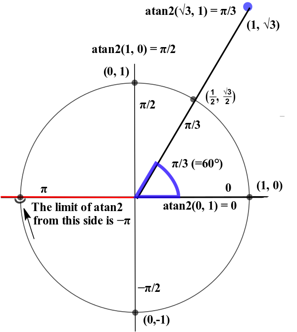

```python
degrees(atan2(1,-1))  # výsledek bude ve stupních
```

```
135.0
```

#### Logaritmické a exponenciální funkce

Modul `math` samozřejmě podporuje exponenciální funkci a také několik funkcí logaritmických:

```python
exp(-1) # e^-1
```

```
0.36788
```

```python
log(16)  # přirozený logaritmus
```

```
2.7726
```

```python
print(log10(16)) # dekadický logaritmus
print(log2(16))  # binární logaritmus (o základu 2)
```

```
1.2041199826559248
4.0
```

> **Úkol**: Vypočtěte logaritmus o základu 3 čísla 81 ($\log_3 81$). Nápověda: je to podíl dvou čísel.

```python
log(81)/log(3)
```

```
4.0
```

*Řešený příklad*:

Zkouška z nejmenovaného předmětu skončila s těmito výsledky: 10% studentů bylo ohodnoceno výborně, 20% velmi dobře, 40% dobře a zbytek (30% neuspěl). Kolik bitů informace získal student, tím že mu vyučující sdělil výsledek zkoušky?

Pokud by byly výsledky zkoušky rozloženy rovnoměrně (25% pravděpodobnost dané známky), je odpověď triviální: čtyři možnosti výsledků lze kódovat dvěmi binárními číslicemi (například takto 00=1, 01=2, 10=3, 11=4), tj. student obdrží přesně dva bity informace (doufám, že informační přínos zkoušky není omezen na tyto dva bity).

Vyšší pravděpodobnost horšího výsledku (pravděpodobnost 3 a hůře je 70%) informační přínos snižuje. Pro výpočet konkrétní hodnoty lze využít Shannonův vztah (kde $p_i$ jsou pravděpodobnosti výskytu i-té možnosti výstupu, zde pravděpodobnosti i-tého výsledků zkoušky):

$H = - \sum_{i=1}^n p_i \cdot \log_2 p_i$

```python
p1 = 0.1
p2 = 0.2
p3 = 0.4
p4 = 0.3

H = -p1*log2(p1) - p2*log2(p2) - p3*log2(p3) - p4*log2(p4)
print(H)
```

```
1.8464393446710154
```

Výsledek: Student získal průměrně 1,85 bitů informací.

#### Funkce pro zaokrouhlování

Zaokrouhlování je jednou z typických operací prováděných při výpočtech na počítačích. Ve skutečnosti jsem již poznali dva typy zaokrouhlení, které se aplikují automaticky:

1. zaokrouhlení dané omezenou přesností interní representace čísel v pohyblivé řádové čárce
2. zaokrouhlení při tisku výsledků (ve skutečnosti se běžně vypisuje menší počet číslic, než je k dispozici v interním formátu). Viz naše nastavení formátování pro výstupy v notebooku.

V praxi však často potřebujeme zaokrouhlování řídit přesněji a explicitněji. Základem zaokrouhlovací aritmetiky jsou funkce `floor` a `ceil`, které zaokrouhlují na nejbližší menší resp. větší celé číslo (a vrací objekt třídy `int`).

```python
floor(pi)
```

```
3
```

```python
ceil(2*pi)
```

```
7
```

Funkce `floor` se někdy chybně zaměňuje s funkcí `int` (= převod na typ `int`). Funkce `int` však jednoduše odsekává destinnou část, což se u záporných čísel liší od funkce `floor` (ta vrací nejbližší nižší celé číslo).

```python
print(int(-2.5))
print(floor(-2.5)) # nejbližší nižší číslo je -3!
```

```
-2
-3
```

Běžné (finanční) zaokrouhlení k nejbližšímu celému číslu provádí funkce `round` (ta je přímo vestavěná takže pro její použití není nutno importovat modul `math`) Pokud je funkce použita v základním tvaru (s jedním parametrem), pak vrací objekt třídy `int`. U čísel s desetinnou částí 0.5 se zaokrouhluje k nejbližšímu sudému číslu.

```python
round(2.5)
```

```
2
```

```python
round(3.5)
```

```
4
```

Funkce kromě zaokrouhlení na nejbližší celé číslo umí i zaokrouhlení k nejbližšímu násobku mocniny desítky (tj. nejen na jednotky, ale i na desítky, stovky, resp. desetiny, setiny, apod). Stačí přidat druhý parametr (označovaný jako `digits`). Zaukrohlení se provede na hodnotu $10^{-digits}$. Výsledek je stejné třídy jako vstupní číslo.

```python
round(2042.0, -3)  # zaokrouhlení na tisíce = 10^3  (výsledek je 'double')
```

```
2000
```

```python
round(2**32, -9)  # zaokrouhlení na miliardy (výsledek je 'int')
```

```
4000000000
```

```python
round(pi, 3) # zaokrouhlení na tisíciny (výsledek je 'double')
```

```
3.142
```

```python
round(3.5, 0)  # zaokrouhlení na jednotky (výsledek však není `int` jak je tomu v round(3.5))
```

```
4
```

> **Úkol**: Vypište hodnotu funkce $sin(x) + cos(x)$ pro $x = \frac{\pi}{4}$ zaokrouhlenou na setiny.

```python
from math import sin,cos,pi
round(sin(pi/4) + cos(pi/4), 2)
```

```
1.41
```

#### Další užitečné funkce

Další užitečné funkce z modulu `math` si ukážeme jen v jednoduchých příkladech.

```python
factorial(69)  # funguje jen pro kladná celá čísla
```

```
171122452428141311372468338881272839092270544893520369393648040923257279754140647424000000000000000
```

```python
n = 100
k = 5

factorial(n)//(factorial(k)*factorial(n-k))
```

```
75287520
```

```python
float(factorial(100))
```

```
9.332621544394415e+157
```

Další užitečnou funkcí je druhá odmocnina.

```python
sqrt(16)  # odmocnina, funguje jen pro kladná čísla (ověřte co dělá pro záporná)
```

```
4
```

Odmocnění lze samozřejmě zapsat i pomocí operátoru mocniny, ale může to být méně efektivní (závisí na procesoru a oprimalizaci Pythonu).

```python
16 ** 0.5    # méně přehledné a pravděpodobně i o něco pomalejší
```

```
4
```

Nepřesnost čísel v pohyblivé řádové čárce (`float`) se může jevit jako drobná kosmetická vada, kterou lze navíc odstranit vhodným zaokrouhlení při výpise. I když tomu tak v mnoha případech opravdu je, existují výjimky, kdy i použití elementárních funkcí vede k překvapivě velkým chybám. V těch nejextrémnějších případech nemusí výsledek obsahovat ani jedinou platnou číslici (jinak řečeno je to hausnumero). Problémem je i zbytečné přetečení v mezivýsledku.

Z tohoto důvodu modul `math` podporuje i zdánlivě nadbytečné funkce, které jsou však navrženy tak, aby tyto případy alespoň částečně eliminovaly.

Ďábel zbytečného přetečení je ukryt i v běžných výpočtech. Vezměme například výpočet délky přepony ze známých délek odvěsen (tento výpočet se využívá i pro výpočet (eukleidovských) vzdáleností v rovině).

```python
a = 5e200
b = 6e200
c = sqrt(a*a + b*b)
print(c)
```

```
inf
```

Trojúhelník s odvěsnami s délkou v řádu $10^{200}$ je obtížně představitelný (a to i v případě, že by délkovou jednotkou byla Planckova délka a trojúhelníkem mince ningy = 1/8 triganského pu). Přesto je však výpočet pro dané `float` hodnoty možný i v omezené počítačové aritmetice. Stačí využít specializovanou funkci `hypot` (není to žádná magie, podívejte se na Wikipedii na článek https://en.wikipedia.org/wiki/Hypot).

```python
a = 5e200
b = 6e200
c = hypot(a, b)
print(c)
```

```
7.810249675906654e+200
```

# 3. Podmínky a větvení programu

## Pravdivostní hodnoty

Kromě číselných objektů podporuje Python i další třídy jednoduchých (tj. nesložených) objektů. Klíčovou roli hrají především tzv. logické resp. pravdivostní hodnoty (*logical, truth*).

Logické hodnoty representují výsledek vyhodnocení tzv. výroku, tj. tvrzení, které je buď pravdivé nebo nepravdivé (v jednoduché logice může nastat právě jedna z těchto situací a žádná jiná). Z tohoto důvodu existují jen dvě pravdivostní hodnoty -- `True`, representující pravdivost a `False` representující nepravdu (lež). Tyto hodnoty patří v Pythonu do jediné třídy označované `bool` (zkratka z označení boolovská (*boolean*) algebra, což je algebraický model dvouhodnotové logiky pojmenovaný podle anglického matematika George Boola).

Pravdivostní hodnoty jsou nejčastěji výsledkem vyhodnocení tzv. relačních operátorů, které umožňují zapisovat výroky o rovnosti, či identitě objektů resp. o jejich upořádání.

#### Relace rovnosti

Základním relačním operátorem je operátor rovnosti zapisovaný pomocí dvou rovnítek (jedno rovnítko má v Pythonu jiný význam, používá se pro přiřazení).

```python
2 == 3
```

```
False
```

Tento výrok je triviální, neboť jakékoliv celé číslo se rovná pouze samo sobě. Výroky porovnávající celá čísla mohou být i složitější, vlastní porovnání je však triviální (a zcela v souhlase s matematikou).

```python
a = 3
b = 10
b % a == b - 3 * a  # výsledek ověřte
```

```
True
```

> Úkol: Pro několik čísel `n` ověřte, že platí $a^2 - b^2 = (a-b)\cdot(a+b)$

```python
a = 2
b = 3
a**2 - b**2 == (a-b)*(a+b)
```

```
True
```

U necelých čísel rovnost závisí na interní representaci třídy `float`. Dvě `float` čísla jsou shodná, pokud mají stejnou representaci. To je ve většině případů ve shodě s matematickou definicí.

```python
from math import *

print( pi == 22/7 )  # pi se skutečně nerovná tomuto zlomku
print( 1/3 == 2/6 ) # to by se rovnat mělo
```

```
False
True
```

Dozajista však už pro vás není překvapením, že výsledek může být občas z hlediska matematiky mírně řečeno překvapující:

```python
3 * 0.1 == 0.3  # to v matematice platí (ve světě čísel `float` nikoliv)
```

```
False
```

```python
x = 1e16
x + 1 == x   # to je naopak v matematice nepravda ( 0 ≠ 1)
```

```
True
```

Z tohoto důvodu se pro testování čísel třídy `float` často používá nasledující obrat:

```python
x = sin(pi/4)
y = sqrt(2)/2
epsilon = 1e-15
```

```python
(abs(x-y) < epsilon)  # x a y je přibližně rovno (s chybou menší než zvolené epsilonT)
```

```
True
```

Přibližná nerovnost řeší většinu problémů s porovnáním čísla třídy `float`. V běžném světě stačí vědět, že $\sin\frac{\pi}{4}$ se od $\frac{\sqrt{2}}{2}$ liší méně než o zanedbatelných $10^{-15}$ (to že jsou zcela shodné by měl sice vědět každý středoškolák, ale i ti co si to pamatují to ve valné většině nedovedou dokázat). Úplně dokonalé řešení to však není, neboť:

1. u komplexnějších výpočtů může být chyba výrazně větší než námi zvolené `epsilon`. Lze ho sice zvolit i větší, ale pak naopak můžeme označit za rovná i čísla, která by měla být rozdílná. Např. zvolíme-li `epsilon = 1e-10`, pak dokážeme, že gravitační konstanta je nulová a gravitační síla neexistuje!
2. přibližná nerovnost neřeší problémy s absolutní ztrátou klíčové informace, jako je tomu v případě pravdivosti výrazu `x + 1 == x`. I když se pokusíte k číslo `1e16` přičíst jedničku opakovaně (potenciálně i nekonečněkrát) stále jeho hodnotu nezvýšíte!
3. zápis není zdaleka tak elegantní a čitelný jako přímé porovnání (takže i zkušení programátoři navzdory nebezpečí dávají přednost běžnému porovnání).

Python nově obsahuje i funkci, která porovnání čísel typu `float` usnadňuje (je součástí modulu `math`).

```python
isclose(sin(pi/4), sqrt(2)/2)
```

```
True
```

Tato funkce je o něco inteligentnější než náš návrh.

> **Úkol:** podívejte se na dokumentaci funkce na https://docs.python.org/3/library/math.html Proč je knihovní funkce lepší, než náš návrh.

#### Ostatní relační operátory

Rovnost je základním relačním operátorem. Existují však samozřejmě i další (z nichž ten s operátorem `<` jsme již použili). Shrňme si je v tabulce:

[output not shown]

Jejich použití je obdobné rovnosti. Pro celá čísla využivá přirozené uspořádání čísel. U čísel typu `float` je pouze rozumným přiblížením matematickým relacím a výsledky tak mohou být překvapivé resp. je nelze vůbec rozumně využít (u skutečně malých a skutečněvelkých čísel).

```python
pi < 4
```

```
True
```

V Pythonu lze navíc nerovnosti řetězit, tj. lze psát podmínky typu $x < y \leq z$.

```python
2 < 3 < 4 <= 4 < 6
```

```
True
```

A o trochu praktičtější příklad:

```python
a = 0.0
b = 10.0
x = 10.0

# x leží v otevřeném intervalu (a,b)
a < x <  b
```

```
False
```

```python
# x leží v uzavřeném intervalu [a,b]
a <= x <= b
```

```
True
```

*Upozornění*: Z důvodů nepřesné representace je rozdíl mezi otevřenými a uzavřenými intervaly spíše kosmetický. Oba zápisy (s operátorem `<` resp. `<=`) lze číst jako, dolní (resp. horní) mez je někde v (těsné) blízkosti `a` resp. `b`.

#### Logické spojky

Testování přítomnosti bodu v intervalu lze alternativně zapsat i pomocí logoické spojky `and` (česky *a zároveň*). Zápis je o něco delší a pro začátečníky i méně čitelný, je však použitelný téměř ve všech programovacích jazycích.

```python
# x leží v uzavřeném intervalu [a,b]
a <= x and  x <= b
# čteme a je menší než x a zároveň x je menší nebo rovno b (obě dílčí podmínky musí být splněny)
```

```
True
```

Při složitějších podmínkách je použití logických spojek nezbytností. Pokud chceme testovat zda číslo leží vně intervalu [a,b] (tj. výraz je pravdivý, pokud leží mimo), pak se logické spojce nevyhneme. Máme přitom hned několik možností.

```python
# negace zřetězených relací
not (a <= x <= b)
# čteme: neplatí tvrzení, že a je menší nebo rovno než x, které je menší nebo rovno než b
```

```
False
```

```python
# negace výrazu s logickou spojkou AND
not (a <= x and x <= b)
```

```
False
```

Nejjednodušší je však zápis využívající spojky OR (česky *nebo*):

```python
x < a or x > b
```

```
False
```

Tuto podmínku lze vymyslet přímo. Číslo leží vně intervalu [a,b] pokud je menší než dolní mez nebo pokud je větší než horní mez (stačí splnění jedné dílčí podmínky). Podívejte se na obrázek.

[figure not shown]

   V našem případě dostaneme podmínku `not(a <= x) or not(x <= b)`.
2. Využijeme skutečnosti, že negací relace `<=` je `>` (a opačně). Pozor skutečně neplatí, že negací ostré nerovnosti (např. menší než) je opačná ostrá nerovnost (např. větší než)! Negací ostré nerovnosti ($<$) je neostrá ($ \geq$) a vice versa.

   V našem případě dostaneme podmínku `a > x or x > b`. První porovnání lze samozřejmě otočit, čímž dostaneme požadovaný tvar `x < a or x > b`.

*Řešený příklad*: Napište podmínku, která ověří, že celé číslo (`int`) označené identifikátorem `i` je kladné sudé číslo.

Testování kladnosti je snadné. Číslo je kladné pokud je (ostře) větší než 0. Na druhou stranu Python nemá vestavěnou funkci na testování sudosti, můžeme však vyjít z jednoduché definice, že číslo je sudé pokud je dělitelné dvěma beze zbytku (tj. zbytek pod celočíselném dělení dvěma je nula).

Obě podmínky spojíme logickou spojkou AND (číslo musí zároveň kladné i sudé).

```python
i = 42   # náhodně zvolené číslo (zkuste jej změnit)
i > 0 and i % 2 == 0
```

```
True
```

Všimněte si priority operací. Nejvyšší prioritu mají aritmetické operace (zde je to zbytek po dělení), pak se provedou relační operátory a nakonec se provede operátor s nejnižší prioritou – logická spojka AND.

[konec příkladu]

> **Úkol:** Napište výraz, který ověří, že číslo označené proměnou `x` je nezáporné ($\ge 0$) jen za použití operátoru rovnosti (rada: použijte elementární funkci).

```python
x = 2.0
abs(x) == x
```

```
True
```

## Speciální hodnoty (ne-hodnoty)

Kromě běžných hodnot (objektů), které representují reálné objekty dané třídy existují v Pythonu hodnoty, které representují neexistenci hodnoty resp. její nedostupnost.

#### Hodnota `None`

Základní nehodnotou je `None`. (Ne)hodnota `None` může být interpretována jako neexistující hodnota libovolné třídy (resp. dokonce jako hodnota bez určení třídy či mimo jakoukoliv rozumnou třídu).

```python
i = None
```

Proměnná `i` nyní sice existuje, označuje však hodnotu, která representuje "nic". Méně kostrbatě: existuje, ale nic neoznačuje.

`None` nejčastěji vyjadřuje dva významy:

1. Hodnota není dostupná (not available), například rok založení Prahy
2. Hodnota není aplikovatelná (například spotřeba paliva u elektromobilu)

S hodnotou `None` lze provádět jen jedinou operaci, porovnávat ji samu se sebou nebo s ostatními hodnotami (libovolné třídy). `None` je nicméně rovna jen sama sobě. Proto je efektivnější testovat `None` na identitu a nikoliv na rovnost (existuje jen jeden objekt `None`).

Identita je nejstriktnějším typem rovnosti, neboť dva objekty jsou identické, pokud zaujímají stejné místo v paměti (resp. abstraktněji v časoprostoru).

Rozdíl mezi identitou a rovností lze vysvětlit i na příkladu z běžného světa. Každá bankovka 100 Kč je rovna jakékoliv bankovce 100 Kč (z hlediska hlavního použití, jímž je placení). Můžeme navrhnout i striktnější definici rovnosti (shody) bankovek. Bankovky jsou rovné, pokud nesou stejný identifikátor (tj. číslo bankovky). Nocměné nelze zcela vyloučit situaci, kdy uvidíte najednou dvě bankovky se stejným číslem, které leží vedle sebe (tj. zaujímají různé místo v prostoru). Je zřejmé, že i když jsou podle všech kritérii shodné, nejsou identické.

```python
i == None # testování rovnosti (funguje, ale je pomalé)
```

```
True
```

```python
i is None # doporučené testování, zda je hodnota None
```

```
True
```

Operátor `is` testuje zde je levý operand identický s pravým. V Pythonu se příliš nepoužívá, neboť ve většině případů je důležitější běžná rovnost. Výjimkou jsou jen některé speciální objekty (včetně `None`).

Pokud například použijeme test identity na celá čísla, můžeme získat dosti překvapivé a na zdánlivě rozporné výsledky.

```python
2 is (1 + 1)
```

```
True
```

```python
(2 ** 100) is (2 ** 100)
```

```
False
```

V případě malých čísel platí, že jsou-li výsledky operací rovné pak jsou i identické. Důvodem je skutečnost, že Python šetří paměť tím, že v případě malých čísel uchovává jen jednu kopii celého čísla (často existuje již od okamžiku spuštění programu a nikdy není uvolněno). U velkých čísel je však dlouhodobé uchovávání čísel neefektivní a tak se tyto objekty chovají podle základního modelu. Při výpočtu vznikají vždy nové a poté co je nikdo neodkazuje dochází k destrukci.

> **Úkol**: Oveřte co jsou ve Vašem Pythonu malá a velká čísla (vzhledem k identitě nově vzniklých objektů).

```python
(255 + 1) is (255 + 1)  # poslední "malé" číslo (ve vašem překladači to může být i jiné)
```

```
True
```

O tom jaký přístup ke sdílení čísel bude zvolen rozhoduje překladač a může záviset i na vnějších parametrech (např. velikost operační paměti). Nelze jej proto predikovat a využívat v programu (např. pro urychlení). Důsledek je proto zřejmý: **nikdy nepoužívejte operátor `is` pro testování rovnosti čísel**.

Porovnání (resp. testování identity) je jedinou operací, kterou lze s hodnotou `None` rozumně provádět. Lze ji sice vypsat funkcí `print`, avšak výstupy se mohou lišit podle použitého Pythonu.

```python
print(None)
```

```
None
```

Ostatní operace vyvolají výjimku (tj. výpočet či program se ani nedokončí).

```python
x = None
x + x
```

```
---------------------------------------------------------------------------
TypeError                                 Traceback (most recent call last)
<ipython-input-35-f75014bbbb7c> in <module>()
      1 x = None
----> 2 x + x

TypeError: unsupported operand type(s) for +: 'NoneType' and 'NoneType'
```

#### Hodnota NaN

V případě čísel v pohyblivé řádové čárce existuje ještě jedna speciální hodnota primárně representující neplatný výsledek některých matematických operací. Tato hodnota je označovabná jako `NaN` tj. *Not A Number*.

```python
import math

x = math.nan
```

Hodnota `NaN` se chová jako numerická hodnota, která není číslem (to není kontradikce). Patří do třídy `float` a lze na ní aplikovat běžné aritmetické operace.

```python
x + x * x
```

```
nan
```

Výsledkem těchto operací je však vždy opět `NaN` (tj. `NaN` se šíří jako epidemie). Tp platí i pro funkce z modulu `math`.

```python
math.sin(x)
```

```
nan
```

S `NaN` se proto v případě číslených hodnot pracuje povětšinou lépe než s hodnotou `None` (ta se nešíří, způsobuje rovnou výjimku a tím i potenciální nebezpečí ukončení porogramu). I ona však má své mouchy. Lze ji sice porovnat s libovolným číslem třídy `float` (resp. i `int` po přizpůsobení typu). Platí však, že se nerovná žádnému objektu a dokonce ani sama sobě! Je to jediná Pythonská hodnota s tímto podivným chováním.

```python
math.nan == math.nan
```

```
False
```

Zde nepomůže ani testování identity. To sice může vrátit `True`, to je však jen implementační detail, který navíc narušuje základní elementární tvrzení: pokud nejsou objekty shodné (rovné) pak nemohou být ani identické. Jediným košer způsobem testování, zda není numerická hodnota rovna `NaN` je funkce `math.isnan`.

```python
math.isnan(x)
```

```
True
```

## Větvení programu

Výrazy vracející pravdivostní hodnoty (podmínky) jsou nejčastěji využívány pro tzv. větvení programu, tj. k vykonání určitého kódu jen za určité situace.

Podmíněné vykonání určité činnosti je samozřejmě známé i z běžného života. Naobědvám se, jen tehdy pokud mám hlad (peníze, čas). Ožením/vdám se, pokud někoho miluji (chci ušetřit na daních, potřebuji získat občanství).

Podmínky v případě počítačového kódu jsou běžně výrazně jednodušší, avšak stejně jako v reálném životě tvoří podmíněné konstrukce podstatnou část programu.

#### Příkaz if

Základní větvící konstrukcí je příkaz `if`, který umožňuje podmíněně vykonávat příkazy (typicky přiřazení, vstupy a výstupy). Příkaz `if` si ukážeme na jednoduchém příkladě. Nejdříve však v si rámci přípravy vypíšeme aktuální verzi Pythonu. Využijeme proměnnou `version_info`, která je poskytována modulem `sys` (zkratka za *běhový **systém***).

```python
import sys  # iportování modulu

sys.version_info
```

```
sys.version_info(major=3, minor=6, micro=3, releaselevel='final', serial=0)
```

Výsledkem je složitý objekt, který obsahuje detailní informaci o verzi aktuálního překladače. Kromě hlavní verze (*major*) obsahuje i číslo dílčí verze (*minor*) a další ještě detailnější údaje. Pokud chceme získat jen hlavní verzi, stačí získat tzv. atribut objektu, uvedením jeho jména za tečkou.

Zápis čteme takto: z modulu `sys` (první tečka) použij proměnnou `version_info`, která odkazuje na objekt, který má atribut se jménem `major`. Atribut odkazuje číselný `int` objekt (jehož hodnota bude vypsána).

```python
sys.version_info.major
```

```
3
```

Nyní již k příkazu `if`, který na základě hodnoty výše uvedeného atributu větví program do dvou větví, z nichž jedna vypíše text *"Používáte správný Python!"* a druhá text *"Používáte zastaralou verzi Pythonu".*

```python
if sys.version_info.major >= 3:
    print("Používáte správný Python!")
else:
    print("Používáte zastaralou verzi Pythonu")
```

```
Používáte správný Python!
```

Nejdříve k **syntaxi** (tj. zápisu) příkazu `if`.

Příkaz `if` začíná klíčovým slovem `if`, za nímž následuje podmínka (tj. výraz, který se vyhodnotí na pravdivostní hodnotu, buď `True` nebo `False`). Poté následuje znak dvojtečky. Tento znak v Pythonu jednoznačně signalizuje, že bude následovat tzv. vnořený blok příkazů.

**Blok příkazů** obsahuje jeden nebo několik příkazů, které tvoří určitý celek. Bloky se v Pythonu definují pomocí odsazení (tj. určitého počtu mezer na začátku řádku). První příkaz v bloku má alespoň o jednu mezeru větší odsazení než předchozí řádek (s dvojtečkou na konci patřící do nadřazeného bloku) tj. je vizuálně více vpravo. Ostatní příkazy v bloku mají stejné odsazení (tj. jsou zarovnány pod sebou). Uvnitř bloku mohou být vnořené bloky (ještě více odsazené). Konec bloku je signalizován návratem k odsazení vnějšího bloku (tj.text je opět méně odsazen tj, začíná víc vlevo). Blok je samozřejmě ukončen i dosažením konce programu.

Zní to složitě, ale je to zcela přirozené. Každým dalším odsazením se dostáváte do hlouběji zanořených bloků, z nichž se pak můžete vracet na vyšší úrovně do nadřazených bloků.

V našem případě je vnořený (osazený) blok tvořen jediným příkazem, který tvoří jednu z větví příkazu `if`.

Poté následuje klíčové slovo `else`, které patří do stejného bloku jako `if`, není tudíž odsazeno. I tento řádek je ukončen dvojtečkou takže lze očekávat, že bude následovat nový vnořený blok, odsazený více vpravo (většina specializovaných editorů včetně Jupyteru proto odsazení vloží automaticky). Tento blok tvoří druhou větev příkazu `if`.

Obecnou syntaxi příkazu `if` tak lze zapsat například takto:

```
if podmínka:
    blok-then
else:
    blok-else
```

Po vyčerpávajícím popisu syntaxe se nyní přesuneme k **sémantice**, tj. k popisu chování konstrukce `if` za běhu aplikace.

Nejdříve dojde k vyhodnocení podmínky. V nejjednodušším případě se podmínka vyhodnotí na objekt třídy `bool`. Tak je tomu i v našem případě, kdy se testuje, zda je hlavní číslo verze větší, nebo rovno třem.

Pokud je výsledkem `True` (což by mělo platit), pak se vykonají příkazy pouze v prvním vnořeném bloku `blok-then` (následuje za řádkem s `if`). V našem případě se vypíše text *"Používáte správný Python!"* (to by mělo skutečně nastat).

V opačném případě (podmínka je vyhodnocena na `false`) se vykonají příkazy druhého vnořeného bloku tj. `blok-else`. V našem příkladě se vykoná příkaz `print` vypisující text "Používáte zastaralou verzi Pythonu".

Všimněte si, že bez ohledu na pravdivost podmínky se provede právě jedna z větví (vnořených bloků) příkazu `if`. Nikdy se neprovedou obě dvě, resp. nehrozí, že by se neprovedla žádná z nich.

> **Úkol**:

> Upravte podmínku předchozího příkazu `if` tak, aby testovala zda je využita verze 3.6 resp. novější (správný Python) a nikoliv verze 3.5 a nižší (zastaralý Python).

> Rada: Je nutné, aby to fungovalo i pro případné nové hlavní verze v budoucnosti např. 4.1 nebo 5.0. Zkuste využít sumární verzi Pythonu například podle vzorce `major * 100 + minor` (vedlejší verze jsou vždy menší než 100).

```python
import sys

if sys.version_info.major * 100 + sys.version_info.minor >= 306:
    print("Verze použitého Pythonu je vyšší nebo rovna 3.6")
else:
    print("Verze použitého Pythonu je menší než 3.6")
```

```
Verze použitého Pythonu je vyšší nebo rovna 3.6
```

Příkaz `if` je jedním z klíčových konstrukcí jazyka Python, takže si uveďmě ještě několik jeho příkladů. Nejdříve si vypočteme trochu divný dvojnásobek celého čísla. Je-li vstupní číslo $x$ sudé, je vypsán skutečný dvojnásobek $2x$, u lichého čísla je vypsána hodnota $2x - 1$ (výsledek tedy zachovává sudost a lichost).

```python
x = int(input("Zadej celé číslo: "))
if x % 2 == 0:  # je-li x sudé
    x *= 2
else: # je-li liché
    x = x*2 - 1
print(x)
```

```
Zadej celé číslo: 27246426228428246248262
54492852456856492496524
```

#### Vstup z konzole (vstupního pole)

Ukázkový program začíná přečtením textu z textového (konzolového) vstupu pomocí vestavěné metody `input`. V případě, že je tato funkce použita v Jupyter notebooku, pak se po každém vyhodnocení vstupní buňky (Ctrl+Shift) objeví vstupní pole, do něhož je možno zadat vstup do programu. Před vstupní pole se napíše text, který je parametrem funkce `input` tzv. výzva (angl. *prompt*).

Výsledkem vyhodnocení funkce `input` je textový objekt, nikoliv číslo (obecně lze totiž zadat zcela libovolný text). Proto je na výsledek funkce `input` zavolána (vestavěná) funkce `int`, která se jakýkoliv rozumný objekt pokusí převést na celé číslo (už jsme se s ní setkali dříve, kdy jsme ji používaly na převod z čísla třídy `float`).

V případě volání na textový objekt (v programátorském slangu na řetězec) je text interpretován jako desítkový zápis nějakého čísla. Výsledkem je interní representace tohoto čísla tj. objekt třídy `int`. Pokud text obsahuje nepřípustné znaky (písmena či např. mezery), je vyvolána výjimka (a výpočet se tudíž nedokončí).

Po načtení následuje větvení programu. Pokud je hodnota označená proměnnou `x` sudá (tj. zbytek po dělení dvěma je roven nula) pak je tato hodnota zdvojnásobena a výsledek je odkazován toutéž proměnnou (složené přiřazení).V opačném případě (větev `else`) je nová hodnota proměnné `x` rovna `2*x - 1` .

Po skončení konstrukce `if` (končí druhý odsazený blok, a následně již není žádné odsazení) je (nepodmíněně) vypsána nová hodnota proměnné `x`.

Vyzkoušejte různé vstupní hodnoty (malá i obrovská celá čísla), neplatný vstup (texty s písmeny, apod.)

**Poznámka**: Předchozí kód je prvním "skutečným" počítačovým programem v tomto textu. Veškerý předchozí kód vracel vždy stejné výsledky při každém spuštění (tj. vyhodnocení). Takový kód lze vyhodnotit i na jednoduché (tj. neprogramovatelné) kalkulačce. Zahrnutím vstupu jsme toto základní omezení překonali a vytvořili, něco co je vícekrát použitelné. Zatím je to spíše potenciál (po ověření funkce pro různé vstupy, pravděpodobně již nikdy daný kód znovu nespustíte), ale je to ten příslovečný *první krok*.

*Řešený příklad*

Náledující program je o malinko složitější, i když stále nepříliš použitelný. Vyžádá si vstup dvou čísel, a nakonec vypíše, které z nich je větší (tj, je to tzv. maximum). Vstupem mohou být tentokráte čísla i desetinnou části (i když na druhé straně omezená na rozsah cca $-10^{308}$ až $10^{308}$.

```python
x = float(input("x: "))
y = float(input("y: "))

if x > y:
    m = x
else:
    m = y
print(f"Maximum je", m)
```

```
x: 3
y: 6
Maximum je 6.0
```

Pro vstup textu je použita opět funkce `input` (dvakrát). Vložený text je však tentokrát převeden na číslo třídy `float` pomocí stejnojmenné funkce. Vstupní hodnoty jsou označeny proměnnými `x` a `y` (v tomto pořadí).

Následně je vyhodnocena podmínka zda je první číslo (označené proměnnou `x`) větší než číslo druhé (proměnná `y`). Pokud tomu tak je, je číslo se štítkem `x` označeno i štítkem `m` (tj.přiřazeno do proměnné `m`).

V opačném případě (druhé číslo je větší nebo rovno [!] prvnímu) je štítkem `m` označeno druhé číslo. Pokud je větší je zřejmé proč (je to určitě maximum). Pokud jsou obě čísla rovna, pak je jedno, které z nich bude označeno za maximum.

Výsledek (tj. číslo označené proměnnou `m`) je vypsán pomocí funkce `print`. Ta je volána se dvěma parametry, které postupně vypisuje. Prvním je text (řetězec) a druhým číslo (objekt označený proměnnou `m`). Všimněte si, že mezi oba výstupy se automaticky vkládá mezera.

[konec řešeného příkladu]

#### Příkaz `if` s jednou větví

V příkazu `if` lze vynechat větev `else`, pokud se v této větvi nemusí nic provádět. Typicky se této konstrukce využívá v případě podmíněného výstupu (výstup se provede jen v případě jisté podmínky) nebo při podmíněném ukončení programu (resp. i jiných konstrukcí).

```python
cislo = int(input())
if cislo == 42:  # pokud je to hledané číslo
    print("Bingo")  # vypíše se text `Bingo`
# v opačném případě se nevypíše nic (větev `else` chybí)
```

```
42
Bingo
```

#### Výjimky

Při programování někdy nastanou situace, které nelze jednoduše vyřešit. Uživatel zadá neplatnou hodnotu, chybí prostředky pro provedení dané činnosti (například neexistuje vstupní soubor, chybí připojení k Internetu, dojde k abolutní ztrátě přesnosti, apod.).

V tomto případě existuje jen jedna správná reakce — vyvolání **výjimky**. Program je přerušen, a pokud kód vyšší úrovně na výjimku nezareaguje, je nakonec i ukončen (s chybovým hlášením). S výjimkami jsme se již setkali, prozatím však vznikaly automaticky v knihovním kódu (tj. kódu nižší úrovně, který jste nenapsali jen ho pasivně využíváte). Výjimky však můžete vyvolávat (spouštět) i sami.

Vyvoláním výjimky se v zásadě zbavujete odpovědnosti za příslušný problém (a přenášíte jej na někoho dalšího, v případě ukončení programu je to uživatel programu). Pokud je problém způsoben vnějšími okolnostmi (chybný vstup, nedostatek prostředků, apod.) je to to nejlepší řešení. Pokud byste problém řešili, pak by se program zbytečně komplikoval a stal se závislým na okolnostech, které nemůžete ovlivnit (například na mechanismu interakce s uživatelem). Platí prosté: **pokud máte problém, který nelze v daném místě vyřešit, pak vyvolejte výjimku.**

PS: Je zřejmé, že pokud je problém ve Vás (například nevíte, jak něco naprogramovat) a děje se to při každém spuštění programu, pak vyvolání výjimky nic nevyřeší (hlavně pokud program vytváříte sami).

A nyní prakticky. Výjimka se vyvolá příkazem `raise` za nímž následuje konstrukce objektu, který nese informaci o tom co se stalo (resp. co se nestalo). Prozatím budeme využívat jen objekty třídy `Exception` (*exception* je angl. výjimka). Vyvolání výjimky je často uvedeno v jednovětvém příkazu `if`, kde podmínka testuje, zda nastal daný problém.

```python
hmotnost = float(input("Zadejte hmotnost předmětu: "))
if hmotnost < 0:  # váš program neumí stejně jako fyzika pracovat se zápornými hmotnostmi
    raise Exception("Záporná hmotnost")  # a pokud to nastane, pak to dále neřešíte (někdo to musí vyřešit za Vás)
```

```
Zadejte hmotnost předmětu: -3
```

```
---------------------------------------------------------------------------
Exception                                 Traceback (most recent call last)
<ipython-input-41-105cc192c62a> in <module>()
      1 hmotnost = float(input("Zadejte hmotnost předmětu: "))
      2 if hmotnost < 0:  # váš program neumí stejně jako fyzika pracovat se zápornými hmotnostmi
----> 3     raise Exception("Záporná hmotnost")  # a pokud to nastane, pak to dále neřešíte (někdo to musí vyřešit za Vás)

Exception: Záporná hmotnost
```

Nyní však na chvíli opusťme řídící konstrukce a zaměřme se na základní možnosti zpracování textů v Pythonu.